# Tugas Praktikum 1 - Pengenalan Data dan Pemulusan MA, Eksponensial, dan Winter

Nesa Saidah Meilani Putri - M0401241021

# 1. Persiapan Data

## Import Data

```r
library(readxl)

data <- read_excel("Data_Wisman_Indonesia_2008_2024.xlsx")
head(data)
```

```
## # A tibble: 6 × 5
##      No Tanggal             Tahun Bulan    Jumlah_Wisman
##   <dbl> <dttm>              <dbl> <chr>            <dbl>
## 1     1 2008-01-01 00:00:00  2008 Januari         437966
## 2     2 2008-02-01 00:00:00  2008 Februari        465449
## 3     3 2008-03-01 00:00:00  2008 Maret           502041
## 4     4 2008-04-01 00:00:00  2008 April           459129
## 5     5 2008-05-01 00:00:00  2008 Mei             508955
## 6     6 2008-06-01 00:00:00  2008 Juni            529064
```

# 2. Eksplorasi Data

```r
View(data)
str(data)
```

```
## tibble [204 × 5] (S3: tbl_df/tbl/data.frame)
##  $ No           : num [1:204] 1 2 3 4 5 6 7 8 9 10 ...
##  $ Tanggal      : POSIXct[1:204], format: "2008-01-01" "2008-02-01" ...
##  $ Tahun        : num [1:204] 2008 2008 2008 2008 2008 ...
##  $ Bulan        : chr [1:204] "Januari" "Februari" "Maret" "April" ...
##  $ Jumlah_Wisman: num [1:204] 437966 465449 502041 459129 508955 ...
```

Diperoleh data jumlah wisatawan mancanegara ke Indonesia sebanyak **204 observasi** dengan **5 variabel**, yaitu `No`, `Tanggal`, `Tahun`, `Bulan`, dan `Jumlah_Wisman`. Data yang digunakan merupakan data bulanan yang dimulai dari **Januari 2008 hingga Desember 2024**.

## Convert Data Menjadi Data Deret Waktu

Selanjutnya, variabel `Jumlah_Wisman` diubah menjadi objek **time series (`ts`)** dengan `frequency = 12`, karena data memiliki frekuensi bulanan.

```r
data.ts <- ts(data$Jumlah_Wisman,
              start = c(2008, 1),
              frequency = 12)

data.ts
```

```
##          Jan     Feb     Mar     Apr     May     Jun     Jul     Aug     Sep
## 2008  437966  465449  502041  459129  508955  529064  567364  599506  501018
## 2009  473165  421555  511314  487121  521735  550582  593415  566797  493799
## 2010  493799  523135  594242  555915  600031  613422  658476  586530  560367
## 2011  548821  568057  598068  608093  600191  674402  745451  621084  650071
## 2012  652692  592502  658602  626100  650883  695531  701200  634194  683584
## 2013  614328  678415  725316  646117  700708  789594  717784  771009  770878
## 2014  753079  702666  765607  726332  752363  851475  777210  826821  791296
## 2015  771066  833000  827069  787282  838030  858359  860703  895420  905806
## 2016  814303  888309  915019  901095  915206  857651 1032741 1031986 1006653
## 2017 1107968 1023388 1059777 1171386 1148588 1144001 1370591 1393243 1250231
## 2018 1097839 1197503 1363426 1302321 1242705 1322674 1547231 1511021 1370943
## 2019 1201735 1243996 1311911 1274231 1249536 1434103 1468173 1530268 1388719
## 2020 1290411  872765  486155  158066  161842  156561  155742  161549  148984
## 2021  126515  105788  119979  112756  139433  126844  127249  118533  120100
```

[output cut: 21 more lines]

## Ringkasan Data Deret Waktu

```r
summary(data.ts)
```

```
##    Min. 1st Qu.  Median    Mean 3rd Qu.    Max.
##  105788  565190  750900  775881 1060340 1547231
```

## Plot Data Deret Waktu

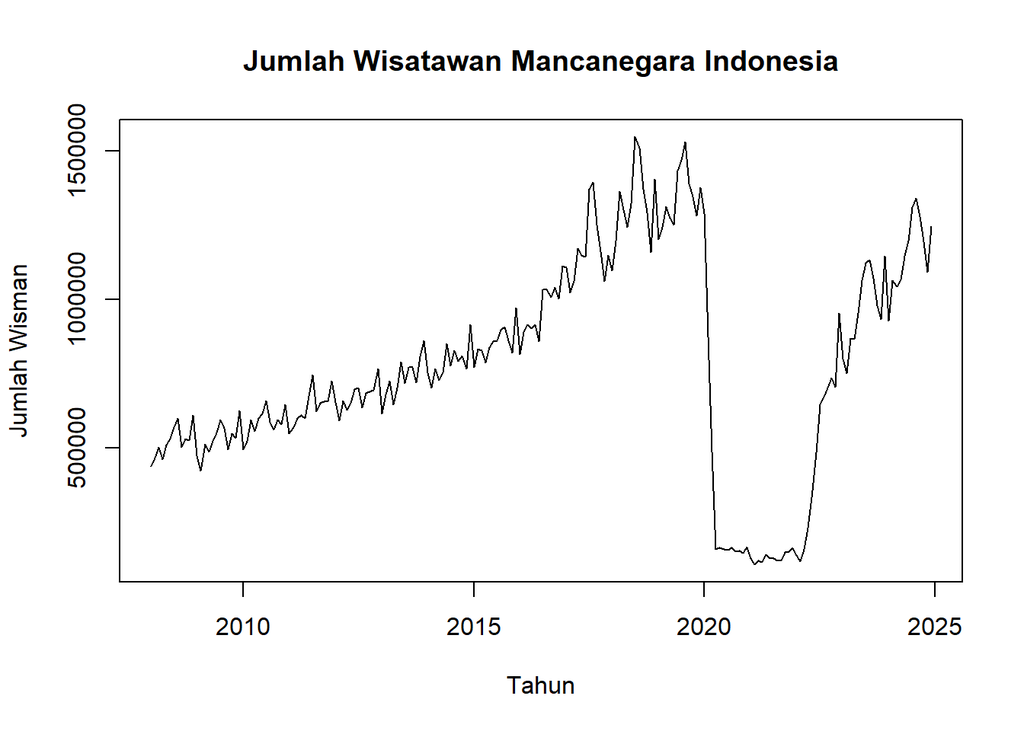

```r
plot(data.ts,
     main = "Jumlah Wisatawan Mancanegara Indonesia",
     xlab = "Tahun",
     ylab = "Jumlah Wisman")
```

**Interpretasi:**

Berdasarkan plot deret waktu, jumlah wisatawan mancanegara mengalami perubahan dari waktu ke waktu. Secara umum terlihat adanya kecenderungan peningkatan jumlah wisatawan pada periode sebelum 2020, kemudian terjadi penurunan yang cukup tajam pada tahun 2020–2021. Setelah periode tersebut, jumlah wisatawan kembali meningkat hingga akhir periode pengamatan.

# 3. Pembagian Data Training dan Testing

Dataset dengan jumlah observasi:
$$n=204$$

Pembagian dilakukan dengan proporsi 80% training:

$$n_{\text{training}}=\lfloor0.8(204)\rfloor=163$$

Sehingga:

$$n_{\text{testing}}=204-163=41$$

Jadi:

- 163 observasi → data latih (training)
- 41 observasi → data uji (testing)

```r
# Hitung jumlah data
n <- nrow(data)

# Tentukan batas 80%
n_train <- floor(0.8 * n)

n
```

```
## [1] 204
```

```r
n_train
```

```
## [1] 163
```

```r
# Membagi data menjadi data training dan testing
training <- data[1:n_train, ]
testing <- data[(n_train + 1):n, ]

# Melihat ukuran masing-masing data
nrow(training)
```

```
## [1] 163
```

```r
nrow(testing)
```

```
## [1] 41
```

```r
# Membuat data time series untuk training dan testing
train.ts <- ts(training$Jumlah_Wisman,
               start = c(2008, 1),
               frequency = 12)

test.ts <- ts(testing$Jumlah_Wisman,
              start = c(2021, 8),
              frequency = 12)

# Melihat data training dan testing
train.ts
```

```
##          Jan     Feb     Mar     Apr     May     Jun     Jul     Aug     Sep
## 2008  437966  465449  502041  459129  508955  529064  567364  599506  501018
## 2009  473165  421555  511314  487121  521735  550582  593415  566797  493799
## 2010  493799  523135  594242  555915  600031  613422  658476  586530  560367
## 2011  548821  568057  598068  608093  600191  674402  745451  621084  650071
## 2012  652692  592502  658602  626100  650883  695531  701200  634194  683584
## 2013  614328  678415  725316  646117  700708  789594  717784  771009  770878
## 2014  753079  702666  765607  726332  752363  851475  777210  826821  791296
## 2015  771066  833000  827069  787282  838030  858359  860703  895420  905806
## 2016  814303  888309  915019  901095  915206  857651 1032741 1031986 1006653
## 2017 1107968 1023388 1059777 1171386 1148588 1144001 1370591 1393243 1250231
## 2018 1097839 1197503 1363426 1302321 1242705 1322674 1547231 1511021 1370943
## 2019 1201735 1243996 1311911 1274231 1249536 1434103 1468173 1530268 1388719
## 2020 1290411  872765  486155  158066  161842  156561  155742  161549  148984
## 2021  126515  105788  119979  112756  139433  126844  127249
##          Oct     Nov     Dec
## 2008  529391  524162  610452
## 2009  547159  531669  625419
## 2010  594654  578152  644221
## 2011  656006  654948  724539
## 2012  688341  693867  766966
## 2013  719903  807422  860655
## 2014  808767  764461  915334
## 2015  861505  820669  971866
## 2016 1040651 1002333 1113328
## 2017 1161565 1062030 1147031
## 2018 1291605 1157483 1405554
## 2019 1346434 1280781 1377067
## 2020  152293  144476  164079
## 2021
```

```r
test.ts
```

```
##          Jan     Feb     Mar     Apr     May     Jun     Jul     Aug     Sep
## 2021                                                          118533  120100
## 2022  136298  117509  158629  230076  354920  483883  645121  670509  700606
## 2023  798469  749436  869244  865811  953714 1062791 1121189 1132638 1070245
## 2024  927746 1062149 1041861 1066958 1145499 1197941 1310756 1339946 1279258
##          Oct     Nov     Dec
## 2021  146137  150577  163619
## 2022  734228  704783  952469
## 2023  978519  931227 1144542
## 2024 1193867 1092067 1244372
```

```r
# Menampilkan periode data training dan testing
start(train.ts)
```

```
## [1] 2008    1
```

```r
end(train.ts)
```

```
## [1] 2021    7
```

```r
start(test.ts)
```

```
## [1] 2021    8
```

```r
end(test.ts)
```

```
## [1] 2024   12
```

Diperoleh:

- Data Training: Januari 2008 – Juli 2021 → 163 observasi
- Data Testing: Agustus 2021 – Desember 2024 → 41 observasi

# 4. Single Moving Average (SMA)

## 4.1 Pemulusan SMA

```r
# Memanggil package TTR untuk fungsi SMA
library(TTR)
# Pemulusan dengan metode Single Moving Average
# menggunakan m = 4
data.sma <- SMA(train.ts, n = 4)

# Melihat hasil pemulusan
data.sma
```

```
##            Jan       Feb       Mar       Apr       May       Jun       Jul
## 2008        NA        NA        NA  466146.2  483893.5  499797.2  516128.0
## 2009  534292.5  507333.5  504121.5  473288.8  485431.2  517688.0  538213.2
## 2010  549511.5  543505.5  559148.8  541772.8  568330.8  590902.5  606961.0
## 2011  591462.0  584812.8  589791.8  580759.8  593602.2  620188.5  657034.2
## 2012  672046.2  656170.2  657083.8  632474.0  632021.8  657779.0  668428.5
## 2013  690875.5  688394.0  696256.2  666044.0  687639.0  715433.8  713550.8
## 2014  785264.8  780955.5  770501.8  736921.0  736742.0  773944.2  776845.0
## 2015  814907.0  820965.2  836617.2  804604.2  821345.2  827685.0  836093.5
## 2016  867085.8  873786.8  897374.2  879681.5  904907.2  897242.8  926673.2
## 2017 1066070.0 1061754.2 1076115.2 1090629.8 1100784.8 1130938.0 1208641.5
## 2018 1117116.2 1126100.8 1201449.8 1240272.2 1276488.8 1307781.5 1353732.8
## 2019 1264094.2 1252192.0 1290799.0 1257968.2 1269918.5 1317445.2 1356510.8
## 2020 1323673.2 1205256.0 1006599.5  701849.2  419707.0  240656.0  158052.8
## 2021  146840.8  135214.5  129090.2  116259.5  119489.0  124753.0  126570.5
##            Aug       Sep       Oct       Nov       Dec
## 2008  551222.2  549238.0  549319.8  538519.2  541255.8
## 2009  558132.2  551148.2  550292.5  534856.0  549511.5
## 2010  614614.8  604698.8  600006.8  579925.8  594348.5
## 2011  660282.0  672752.0  668153.0  645527.2  671391.0
## 2012  670452.0  678627.2  676829.8  674996.5  708189.5
## 2013  744773.8  762316.2  744893.5  767303.0  789714.5
## 2014  801967.2  811700.5  801023.5  797836.2  819964.5
## 2015  863128.0  880072.0  880858.5  870850.0  889961.5
## 2016  959396.0  982257.8 1028007.8 1020405.8 1040741.2
## 2017 1264105.8 1289516.5 1293907.5 1216767.2 1155214.2
## 2018 1405907.8 1437967.2 1430200.0 1332763.0 1306396.2
## 2019 1420520.0 1455315.8 1433398.5 1386550.5 1348250.2
## 2020  158923.5  155709.0  154642.0  151825.5  152458.0
## 2021
```

Dari hasil yang diperoleh, beberapa nilai pada awal data berupa `NA` karena belum tersedia 4 pengamatan sebelumnya untuk menghitung nilai rata-rata. Setelah periode tersebut, nilai pemulusan dapat mengikuti pola data jumlah wisatawan mancanegara.

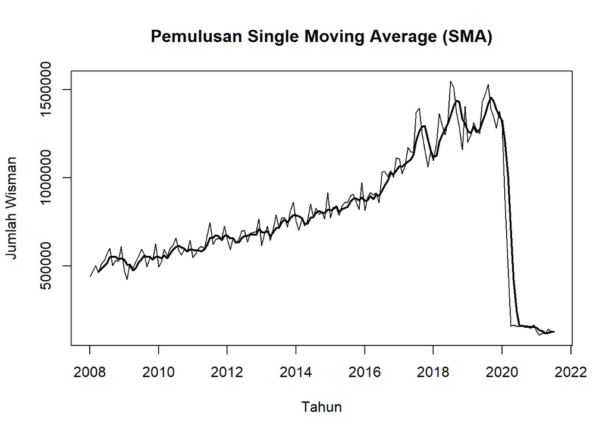

```r
# Plot data aktual dan hasil pemulusan SMA
plot(train.ts,
     main = "Pemulusan Single Moving Average (SMA)",
     xlab = "Tahun",
     ylab = "Jumlah Wisman")

lines(data.sma, lwd = 2)
```

**Interpretasi:**

Berdasarkan plot pemulusan SMA dengan $m=4$, garis hasil pemulusan terlihat lebih halus dibandingkan garis data aktual. Hal ini terjadi karena nilai SMA merupakan rata-rata dari 4 pengamatan sebelumnya. Garis pemulusan masih mengikuti pola umum data, tetapi perubahan yang naik atau turun secara tajam tidak langsung terlihat pada garis SMA. Pada awal periode terdapat beberapa nilai yang belum dapat dihitung karena membutuhkan 4 pengamatan sebelumnya.

## 4.2 Peramalan

```r
# Membuat ramalan 1 periode ke depan
data.ramal <- c(NA, data.sma)

# Melihat hasil ramalan
data.ramal
```

```
##   [1]        NA        NA        NA        NA  466146.2  483893.5  499797.2
##   [8]  516128.0  551222.2  549238.0  549319.8  538519.2  541255.8  534292.5
##  [15]  507333.5  504121.5  473288.8  485431.2  517688.0  538213.2  558132.2
##  [22]  551148.2  550292.5  534856.0  549511.5  549511.5  543505.5  559148.8
##  [29]  541772.8  568330.8  590902.5  606961.0  614614.8  604698.8  600006.8
##  [36]  579925.8  594348.5  591462.0  584812.8  589791.8  580759.8  593602.2
##  [43]  620188.5  657034.2  660282.0  672752.0  668153.0  645527.2  671391.0
##  [50]  672046.2  656170.2  657083.8  632474.0  632021.8  657779.0  668428.5
##  [57]  670452.0  678627.2  676829.8  674996.5  708189.5  690875.5  688394.0
##  [64]  696256.2  666044.0  687639.0  715433.8  713550.8  744773.8  762316.2
##  [71]  744893.5  767303.0  789714.5  785264.8  780955.5  770501.8  736921.0
##  [78]  736742.0  773944.2  776845.0  801967.2  811700.5  801023.5  797836.2
##  [85]  819964.5  814907.0  820965.2  836617.2  804604.2  821345.2  827685.0
##  [92]  836093.5  863128.0  880072.0  880858.5  870850.0  889961.5  867085.8
##  [99]  873786.8  897374.2  879681.5  904907.2  897242.8  926673.2  959396.0
## [106]  982257.8 1028007.8 1020405.8 1040741.2 1066070.0 1061754.2 1076115.2
## [113] 1090629.8 1100784.8 1130938.0 1208641.5 1264105.8 1289516.5 1293907.5
## [120] 1216767.2 1155214.2 1117116.2 1126100.8 1201449.8 1240272.2 1276488.8
## [127] 1307781.5 1353732.8 1405907.8 1437967.2 1430200.0 1332763.0 1306396.2
## [134] 1264094.2 1252192.0 1290799.0 1257968.2 1269918.5 1317445.2 1356510.8
## [141] 1420520.0 1455315.8 1433398.5 1386550.5 1348250.2 1323673.2 1205256.0
## [148] 1006599.5  701849.2  419707.0  240656.0  158052.8  158923.5  155709.0
## [155]  154642.0  151825.5  152458.0  146840.8  135214.5  129090.2  116259.5
## [162]  119489.0  124753.0  126570.5
```

```r
# Membuat data gabungan aktual, pemulusan, dan ramalan
data.gab <- cbind(
  aktual = c(train.ts, test.ts),
  pemulusan = c(data.sma, rep(NA, length(test.ts))),
  ramalan = c(
    data.ramal,
    rep(data.ramal[length(data.ramal)], length(test.ts) - 1)
  )
)

# Melihat hasil gabungan
data.gab
```

```
##         aktual pemulusan   ramalan
##   [1,]  437966        NA        NA
##   [2,]  465449        NA        NA
##   [3,]  502041        NA        NA
##   [4,]  459129  466146.2        NA
##   [5,]  508955  483893.5  466146.2
##   [6,]  529064  499797.2  483893.5
##   [7,]  567364  516128.0  499797.2
##   [8,]  599506  551222.2  516128.0
##   [9,]  501018  549238.0  551222.2
##  [10,]  529391  549319.8  549238.0
##  [11,]  524162  538519.2  549319.8
##  [12,]  610452  541255.8  538519.2
##  [13,]  473165  534292.5  541255.8
##  [14,]  421555  507333.5  534292.5
```

[output cut: 190 more lines]

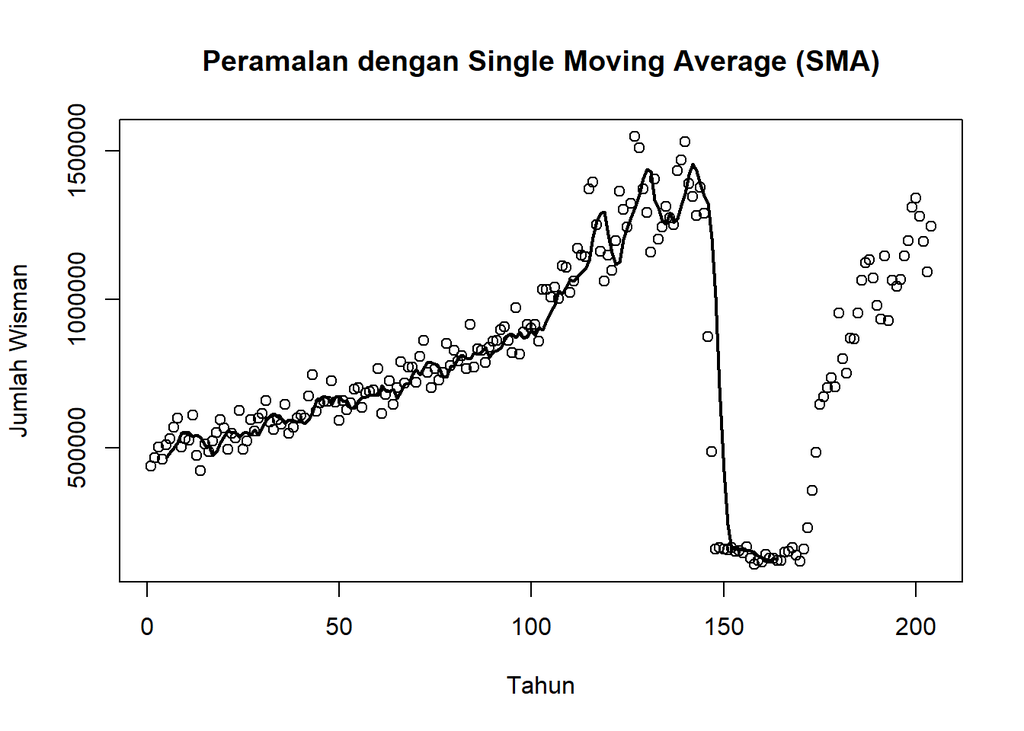

```r
# Plot data aktual dan hasil ramalan
plot(c(train.ts, test.ts),
     main = "Peramalan dengan Single Moving Average (SMA)",
     xlab = "Tahun",
     ylab = "Jumlah Wisman")

lines(data.ramal, lwd = 2)
```

**Interpretasi:**

Pada grafik, nilai ramalan cenderung lebih halus dibandingkan data aktual karena menggunakan rata-rata beberapa pengamatan. Pada periode setelah data training, nilai ramalan relatif mengikuti nilai terakhir yang tersedia sehingga perubahan data yang cukup besar belum dapat diikuti dengan baik.

## 4.3 Akurasi Data Training

```r
# Menghitung error pada data training
error_train.sma <- train.ts - data.ramal[1:length(train.ts)]

# Menghitung akurasi data training
SSE_train.sma <- sum(error_train.sma[5:length(train.ts)]^2)

MSE_train.sma <- mean(error_train.sma[5:length(train.ts)]^2)

MAPE_train.sma <- mean(
  abs(
    (error_train.sma[5:length(train.ts)] /
       train.ts[5:length(train.ts)]) * 100
  )
)

# Membuat tabel akurasi
akurasi_train.sma <- matrix(
  c(SSE_train.sma, MSE_train.sma, MAPE_train.sma)
)

row.names(akurasi_train.sma) <- c("SSE", "MSE", "MAPE")
colnames(akurasi_train.sma) <- c("Akurasi m = 4")

akurasi_train.sma
```

```
##      Akurasi m = 4
## SSE   2.715596e+12
## MSE   1.707922e+10
## MAPE  1.508716e+01
```

Berdasarkan hasil akurasi data training, diperoleh **SSE sebesar $2.715596\times10^{12}$**, **MSE sebesar $1.707922\times10^{10}$**, dan **MAPE sebesar 15.08716%**. Nilai tersebut menunjukkan bahwa pada data training, rata-rata kesalahan persentase hasil ramalan terhadap data aktual sekitar **15%**.

## 4.4 Akurasi Data Testing

```r
# Mengambil hasil ramalan untuk data testing
ramalan_test.sma <- data.gab[
  (length(train.ts) + 1):(length(train.ts) + length(test.ts)),
  "ramalan"
]

# Menghitung error data testing
error_test.sma <- test.ts - ramalan_test.sma

# Menghitung akurasi data testing
SSE_test.sma <- sum(error_test.sma^2)

MSE_test.sma <- mean(error_test.sma^2)

MAPE_test.sma <- mean(
  abs(
    (error_test.sma / test.ts) * 100
  )
)

# Membuat tabel akurasi
akurasi_test.sma <- matrix(
  c(SSE_test.sma, MSE_test.sma, MAPE_test.sma)
)

row.names(akurasi_test.sma) <- c("SSE", "MSE", "MAPE")
colnames(akurasi_test.sma) <- c("Akurasi m = 4")

akurasi_test.sma
```

```
##      Akurasi m = 4
## SSE   2.422315e+13
## MSE   5.908085e+11
## MAPE  7.038539e+01
```

Pada data testing, diperoleh **SSE sebesar $2.422315\times10^{13}$**, **MSE sebesar $5.908085\times10^{11}$**, dan **MAPE sebesar 70.38539%**. Nilai MAPE yang cukup besar menunjukkan bahwa hasil ramalan SMA memiliki kesalahan yang lebih besar pada data testing dibandingkan data training.

## 4.5 Ringkasan Akurasi SMA

```r
# Membuat tabel perbandingan akurasi training dan testing
akurasi_sma <- rbind(
  Training = c(
    SSE = SSE_train.sma,
    MSE = MSE_train.sma,
    MAPE = MAPE_train.sma
  ),
  Testing = c(
    SSE = SSE_test.sma,
    MSE = MSE_test.sma,
    MAPE = MAPE_test.sma
  )
)

akurasi_sma
```

```
##                   SSE          MSE     MAPE
## Training 2.715596e+12  17079218603 15.08716
## Testing  2.422315e+13 590808544453 70.38539
```

Secara keseluruhan, metode SMA dengan $m=4$ menghasilkan kesalahan yang lebih kecil pada data training dibandingkan data testing. Perbedaan nilai MAPE yang cukup besar, yaitu **15.08716% pada training** dan **70.38539% pada testing**, menunjukkan bahwa metode SMA belum dapat mengikuti perubahan data pada periode testing dengan baik.

# 5. Double Moving Average (DMA)

## 5.1 Pemulusan Double Moving Average

```r
# Pemulusan pertama
data.sma <- SMA(train.ts, n = 4)

# Pemulusan kedua
dma <- SMA(data.sma, n = 4)

data.sma
```

```
##            Jan       Feb       Mar       Apr       May       Jun       Jul
## 2008        NA        NA        NA  466146.2  483893.5  499797.2  516128.0
## 2009  534292.5  507333.5  504121.5  473288.8  485431.2  517688.0  538213.2
## 2010  549511.5  543505.5  559148.8  541772.8  568330.8  590902.5  606961.0
## 2011  591462.0  584812.8  589791.8  580759.8  593602.2  620188.5  657034.2
## 2012  672046.2  656170.2  657083.8  632474.0  632021.8  657779.0  668428.5
## 2013  690875.5  688394.0  696256.2  666044.0  687639.0  715433.8  713550.8
## 2014  785264.8  780955.5  770501.8  736921.0  736742.0  773944.2  776845.0
## 2015  814907.0  820965.2  836617.2  804604.2  821345.2  827685.0  836093.5
## 2016  867085.8  873786.8  897374.2  879681.5  904907.2  897242.8  926673.2
## 2017 1066070.0 1061754.2 1076115.2 1090629.8 1100784.8 1130938.0 1208641.5
## 2018 1117116.2 1126100.8 1201449.8 1240272.2 1276488.8 1307781.5 1353732.8
## 2019 1264094.2 1252192.0 1290799.0 1257968.2 1269918.5 1317445.2 1356510.8
## 2020 1323673.2 1205256.0 1006599.5  701849.2  419707.0  240656.0  158052.8
## 2021  146840.8  135214.5  129090.2  116259.5  119489.0  124753.0  126570.5
##            Aug       Sep       Oct       Nov       Dec
## 2008  551222.2  549238.0  549319.8  538519.2  541255.8
## 2009  558132.2  551148.2  550292.5  534856.0  549511.5
## 2010  614614.8  604698.8  600006.8  579925.8  594348.5
## 2011  660282.0  672752.0  668153.0  645527.2  671391.0
## 2012  670452.0  678627.2  676829.8  674996.5  708189.5
## 2013  744773.8  762316.2  744893.5  767303.0  789714.5
## 2014  801967.2  811700.5  801023.5  797836.2  819964.5
## 2015  863128.0  880072.0  880858.5  870850.0  889961.5
## 2016  959396.0  982257.8 1028007.8 1020405.8 1040741.2
## 2017 1264105.8 1289516.5 1293907.5 1216767.2 1155214.2
## 2018 1405907.8 1437967.2 1430200.0 1332763.0 1306396.2
## 2019 1420520.0 1455315.8 1433398.5 1386550.5 1348250.2
## 2020  158923.5  155709.0  154642.0  151825.5  152458.0
## 2021
```

```r
dma
```

```
##            Jan       Feb       Mar       Apr       May       Jun       Jul
## 2008        NA        NA        NA        NA        NA        NA  491491.2
## 2009  540846.8  530350.2  521750.8  504759.1  492543.8  495132.4  503655.3
## 2010  546042.9  544346.1  550419.3  548484.6  553189.4  565038.7  576991.8
## 2011  591435.8  587637.2  590103.8  586706.6  587241.6  596085.6  612896.2
## 2012  664279.4  661283.7  664172.8  654443.6  644437.4  644839.6  647675.8
## 2013  687722.8  690613.9  695928.8  685392.4  684583.3  691343.2  695666.9
## 2014  771793.9  780809.4  781609.1  768410.8  756280.1  754527.2  756113.1
## 2015  808432.8  813418.2  823113.5  819273.4  820883.0  822562.9  822432.0
## 2016  877188.9  875421.0  882052.1  879482.1  888937.4  894801.4  902126.2
## 2017 1038806.2 1047242.8 1061170.2 1073642.3 1082321.0 1099616.9 1132748.5
## 2018 1195751.3 1153799.6 1149970.2 1171234.8 1211077.9 1256498.1 1294568.8
## 2019 1333363.4 1288861.4 1278370.4 1266263.4 1267719.4 1284032.8 1300460.7
## 2020 1372968.1 1315932.5 1220944.8 1059344.5  833352.9  592202.9  380066.2
## 2021  151441.6  146584.7  140900.9  131851.2  125013.3  122397.9  121768.0
##            Aug       Sep       Oct       Nov       Dec
## 2008  512760.2  529096.4  541477.0  547074.8  544583.2
## 2009  524866.2  541295.4  549446.6  548607.2  546452.1
## 2010  595202.2  604294.2  606570.3  599811.5  594744.9
## 2011  632776.8  652564.2  664555.3  661678.6  664455.8
## 2012  657170.3  668821.7  673584.4  675226.4  684660.8
## 2013  715349.3  734018.6  741383.6  754821.6  766056.8
## 2014  772374.6  791114.2  797884.1  803131.9  807631.2
## 2015  837062.9  851744.6  865038.0  873727.1  880435.5
## 2016  922054.8  941392.4  974083.7  997516.8 1017853.1
## 2017 1176117.5 1223300.4 1264042.8 1266074.2 1238851.4
## 2018 1335977.7 1376347.3 1406951.9 1401709.5 1376831.6
## 2019 1341098.6 1387447.9 1416436.2 1423946.2 1405878.8
## 2020  244334.8  178335.3  156831.8  155275.0  153658.6
## 2021
```

```r
# Menghitung komponen level (At)
At <- 2 * data.sma - dma

# Menghitung komponen tren (Bt)
Bt <- 2 / (4 - 1) * (data.sma - dma)

At
```

```
##              Jan         Feb         Mar         Apr         May         Jun
## 2008          NA          NA          NA          NA          NA          NA
## 2009  527738.188  484316.750  486492.188  441818.438  478318.750  540243.625
## 2010  552980.125  542664.875  567878.188  535060.875  583472.062  616766.312
## 2011  591488.250  581988.250  589479.750  574812.938  599962.875  644291.438
## 2012  679813.125  651056.812  649994.688  610504.438  619606.062  670718.375
## 2013  694028.188  686174.125  696583.688  646695.562  690694.688  739524.250
## 2014  798735.562  781101.562  759394.375  705431.250  717203.938  793361.250
## 2015  821381.188  828512.250  850121.000  789935.062  821807.500  832807.062
## 2016  856982.562  872152.500  912696.438  879880.938  920877.062  899684.062
## 2017 1093333.812 1076265.688 1091060.312 1107617.188 1119248.500 1162259.062
## 2018 1038481.188 1098401.875 1252929.250 1309309.750 1341899.625 1359064.938
## 2019 1194825.125 1215522.625 1303227.625 1249673.125 1272117.562 1350857.750
## 2020 1274378.375 1094579.500  792254.250  344354.000    6061.062 -110890.938
## 2021  142239.938  123844.312  117279.625  100667.750  113964.688  127108.062
##              Jul         Aug         Sep         Oct         Nov         Dec
## 2008  540764.750  589684.250  569379.625  557162.500  529963.688  537928.312
## 2009  572771.188  591398.312  561001.062  551138.438  521104.750  552570.938
## 2010  636930.250  634027.250  605103.250  593443.188  560040.000  593952.062
## 2011  701172.312  687787.250  692939.812  671750.688  629375.938  678326.188
## 2012  689181.188  683733.688  688432.812  680075.125  674766.625  731718.250
## 2013  731434.625  774198.188  790613.875  748403.438  779784.375  813372.188
## 2014  797576.938  831559.875  832286.750  804162.938  792540.625  832297.812
## 2015  849755.000  889193.062  908399.375  896679.000  867972.875  899487.500
## 2016  951220.312  996737.188 1023123.062 1081931.812 1043294.688 1063629.375
## 2017 1284534.500 1352094.000 1355732.562 1323772.188 1167460.250 1071577.125
## 2018 1412896.688 1475837.812 1499587.188 1453448.062 1263816.500 1235960.875
## 2019 1412560.812 1499941.375 1523183.562 1450360.750 1349154.812 1290621.750
## 2020  -63960.750   73512.188  133082.688  152452.188  148376.000  151257.375
## 2021  131373.000
```

```r
Bt
```

```
##               Jan          Feb          Mar          Apr          May
## 2008           NA           NA           NA           NA           NA
## 2009   -4369.5417  -15344.5000  -11752.8750  -20980.2083   -4741.6667
## 2010    2312.4167    -560.4167    5819.6250   -4474.5833   10094.2083
## 2011      17.5000   -1883.0000    -208.0000   -3964.5417    4240.4167
## 2012    5177.9167   -3408.9583   -4726.0417  -14646.3750   -8277.1250
## 2013    2101.7917   -1479.9167     218.2917  -12898.9583    2037.1250
## 2014    8980.5417      97.3750   -7404.9167  -20993.1667  -13025.3750
## 2015    4316.1250    5031.3333    9002.5000   -9779.4583     308.1667
## 2016   -6735.4583   -1089.5000   10214.7917     132.9583   10646.5417
## 2017   18175.8750    9674.2917    9963.3750   11324.9583   12309.1667
## 2018  -52423.3750  -18465.9167   34319.6667   46025.0000   43607.2500
## 2019  -46179.4167  -24446.2500    8285.7500   -5530.0833    1466.0417
## 2020  -32863.2500  -73784.3333 -142896.8333 -238330.1667 -275763.9583
## 2021   -3067.2083   -7580.1250   -7873.7500  -10394.5000   -3682.8750
```

[output cut: 30 more lines]

```r
# Peramalan DMA
data.dma <- At + Bt

data.dma
```

```
##             Jan        Feb        Mar        Apr        May        Jun
## 2008         NA         NA         NA         NA         NA         NA
## 2009  523368.65  468972.25  474739.31  420838.23  473577.08  555280.71
## 2010  555292.54  542104.46  573697.81  530586.29  593566.27  634008.85
## 2011  591505.75  580105.25  589271.75  570848.40  604203.29  660360.06
## 2012  684991.04  647647.85  645268.65  595858.06  611328.94  679344.62
## 2013  696129.98  684694.21  696801.98  633796.60  692731.81  755584.58
## 2014  807716.10  781198.94  751989.46  684438.08  704178.56  806305.92
## 2015  825697.31  833543.58  859123.50  780155.60  822115.67  836221.77
## 2016  850247.10  871063.00  922911.23  880013.90  931523.60  901311.60
## 2017 1111509.69 1085939.98 1101023.69 1118942.15 1131557.67 1183139.77
## 2018  986057.81 1079935.96 1287248.92 1355334.75 1385506.88 1393253.90
## 2019 1148645.71 1191076.38 1311513.38 1244143.04 1273583.60 1373132.75
## 2020 1241515.12 1020795.17  649357.42  106023.83 -269702.90 -345255.56
## 2021  139172.73  116264.19  109405.88   90273.25  110281.81  128678.10
##             Jul        Aug        Sep        Oct        Nov        Dec
## 2008  557189.25  615325.58  582807.38  562391.00  524259.98  535710.02
## 2009  595809.81  613575.69  567569.60  551702.40  511937.25  554610.56
## 2010  656909.75  646968.92  605372.92  589067.48  546782.83  593687.77
## 2011  730597.69  706124.08  706398.35  674149.15  618608.40  682949.65
## 2012  703016.31  692588.15  694969.85  682238.71  674613.38  747404.08
## 2013  743357.21  793814.48  809478.96  750743.40  788105.29  829143.98
## 2014  811398.23  851288.29  846010.92  806255.90  789010.21  840520.02
## 2015  858862.67  906569.77  927284.29  907226.00  866054.79  905838.17
## 2016  967585.02 1021631.31 1050366.60 1117881.19 1058553.98 1078888.12
## 2017 1335129.83 1410752.83 1399876.60 1343681.98 1134588.92 1015819.04
## 2018 1452339.31 1522457.85 1540667.15 1468946.77 1217852.17 1189003.96
## 2019 1449927.52 1552888.96 1568428.77 1461668.92 1324224.35 1252202.75
## 2020 -211969.75   16571.31  117998.48  150992.31  146076.33  150456.96
## 2021  134574.67
```

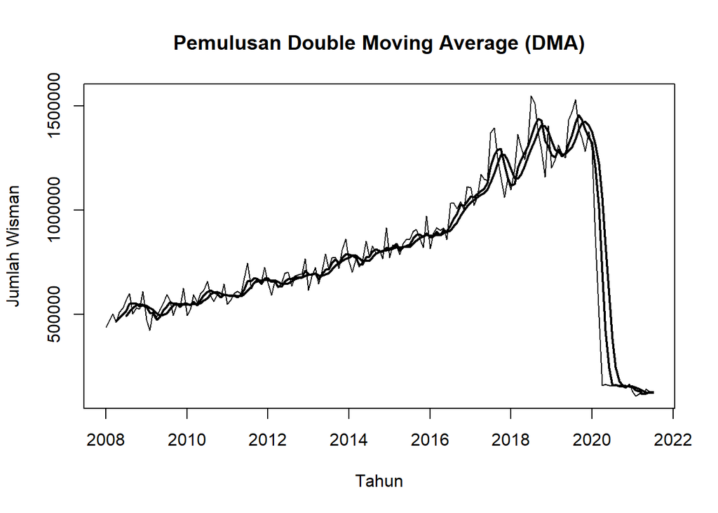

```r
plot(train.ts,
     main = "Pemulusan Double Moving Average (DMA)",
     xlab = "Tahun",
     ylab = "Jumlah Wisman")

lines(data.sma, lwd = 2)
lines(dma, lwd = 2)
```

**Interpretasi:**

Berdasarkan hasil plot, pemulusan DMA menghasilkan garis yang lebih halus dibandingkan data aktual. Pola kenaikan dan penurunan data masih terlihat, tetapi perubahan yang terjadi secara tiba-tiba menjadi lebih halus karena proses pemulusan dilakukan sebanyak dua kali. Pada bagian awal data terdapat beberapa nilai `NA` karena belum tersedia pengamatan yang cukup untuk melakukan dua tahap pemulusan.

## 5.2 Peramalan dengan DMA

```r
# Membuat data ramalan DMA
data.ramal2 <- c(NA, data.dma)

data.ramal2
```

```
##   [1]         NA         NA         NA         NA         NA         NA
##   [7]         NA  557189.25  615325.58  582807.38  562391.00  524259.98
##  [13]  535710.02  523368.65  468972.25  474739.31  420838.23  473577.08
##  [19]  555280.71  595809.81  613575.69  567569.60  551702.40  511937.25
##  [25]  554610.56  555292.54  542104.46  573697.81  530586.29  593566.27
##  [31]  634008.85  656909.75  646968.92  605372.92  589067.48  546782.83
##  [37]  593687.77  591505.75  580105.25  589271.75  570848.40  604203.29
##  [43]  660360.06  730597.69  706124.08  706398.35  674149.15  618608.40
##  [49]  682949.65  684991.04  647647.85  645268.65  595858.06  611328.94
##  [55]  679344.62  703016.31  692588.15  694969.85  682238.71  674613.38
##  [61]  747404.08  696129.98  684694.21  696801.98  633796.60  692731.81
##  [67]  755584.58  743357.21  793814.48  809478.96  750743.40  788105.29
##  [73]  829143.98  807716.10  781198.94  751989.46  684438.08  704178.56
##  [79]  806305.92  811398.23  851288.29  846010.92  806255.90  789010.21
##  [85]  840520.02  825697.31  833543.58  859123.50  780155.60  822115.67
##  [91]  836221.77  858862.67  906569.77  927284.29  907226.00  866054.79
##  [97]  905838.17  850247.10  871063.00  922911.23  880013.90  931523.60
## [103]  901311.60  967585.02 1021631.31 1050366.60 1117881.19 1058553.98
## [109] 1078888.12 1111509.69 1085939.98 1101023.69 1118942.15 1131557.67
## [115] 1183139.77 1335129.83 1410752.83 1399876.60 1343681.98 1134588.92
## [121] 1015819.04  986057.81 1079935.96 1287248.92 1355334.75 1385506.88
## [127] 1393253.90 1452339.31 1522457.85 1540667.15 1468946.77 1217852.17
## [133] 1189003.96 1148645.71 1191076.38 1311513.38 1244143.04 1273583.60
## [139] 1373132.75 1449927.52 1552888.96 1568428.77 1461668.92 1324224.35
## [145] 1252202.75 1241515.12 1020795.17  649357.42  106023.83 -269702.90
## [151] -345255.56 -211969.75   16571.31  117998.48  150992.31  146076.33
## [157]  150456.96  139172.73  116264.19  109405.88   90273.25  110281.81
## [163]  128678.10  134574.67
```

```r
data.gab2 <- cbind(
  aktual = c(train.ts, test.ts),
  pemulusan = c(data.dma, rep(NA, length(test.ts))),
  ramalan = c(
    data.ramal2,
    rep(data.ramal2[length(data.ramal2)], length(test.ts) - 1)
  )
)

data.gab2
```

```
##         aktual  pemulusan    ramalan
##   [1,]  437966         NA         NA
##   [2,]  465449         NA         NA
##   [3,]  502041         NA         NA
##   [4,]  459129         NA         NA
##   [5,]  508955         NA         NA
##   [6,]  529064         NA         NA
##   [7,]  567364  557189.25         NA
##   [8,]  599506  615325.58  557189.25
##   [9,]  501018  582807.38  615325.58
##  [10,]  529391  562391.00  582807.38
##  [11,]  524162  524259.98  562391.00
##  [12,]  610452  535710.02  524259.98
##  [13,]  473165  523368.65  535710.02
##  [14,]  421555  468972.25  523368.65
```

[output cut: 190 more lines]

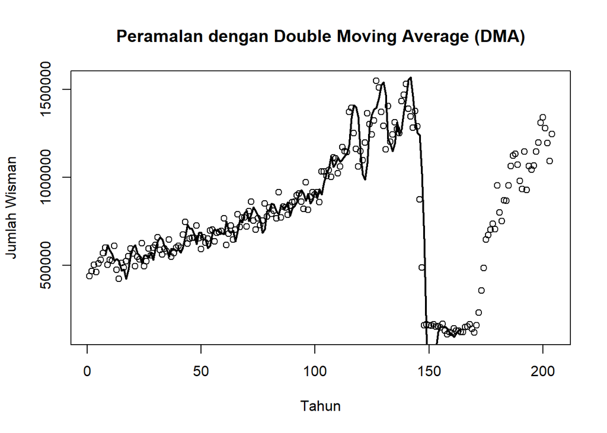

```r
plot(c(train.ts, test.ts),
     main = "Peramalan dengan Double Moving Average (DMA)",
     xlab = "Tahun",
     ylab = "Jumlah Wisman")

lines(data.ramal2, lwd = 2)
```

**Interpretasi:**

Berdasarkan plot peramalan DMA, hasil ramalan cenderung lebih halus dibandingkan data aktual. Pada data training, ramalan masih mengikuti pola umum perubahan jumlah wisatawan, meskipun terdapat beberapa perbedaan dengan nilai aktual.

## 5.3 Akurasi Data Training

```r
error_train.dma <- train.ts - data.ramal2[1:length(train.ts)]

SSE_train.dma <- sum(error_train.dma[8:length(train.ts)]^2)

MSE_train.dma <- mean(error_train.dma[8:length(train.ts)]^2)

MAPE_train.dma <- mean(
  abs(
    (error_train.dma[8:length(train.ts)] /
       train.ts[8:length(train.ts)]) * 100
  )
)

akurasi_train.dma <- matrix(
  c(SSE_train.dma, MSE_train.dma, MAPE_train.dma)
)

row.names(akurasi_train.dma) <- c("SSE", "MSE", "MAPE")
colnames(akurasi_train.dma) <- c("Akurasi DMA m = 4")

akurasi_train.dma
```

```
##      Akurasi DMA m = 4
## SSE       2.475110e+12
## MSE       1.586609e+10
## MAPE      1.731724e+01
```

Berdasarkan hasil akurasi data training, diperoleh **SSE sebesar $2.475110\times10^{12}$**, **MSE sebesar $1.586609\times10^{10}$**, dan **MAPE sebesar 17.31724%**.

Nilai MAPE tersebut menunjukkan bahwa rata-rata kesalahan persentase hasil ramalan DMA terhadap data aktual pada data training sekitar **17.32%**.

## 5.4 Akurasi Data Testing

```r
ramalan_test.dma <- data.gab2[
  (length(train.ts) + 1):(length(train.ts) + length(test.ts)),
  "ramalan"
]

error_test.dma <- test.ts - ramalan_test.dma

SSE_test.dma <- sum(error_test.dma^2)

MSE_test.dma <- mean(error_test.dma^2)

MAPE_test.dma <- mean(
  abs(
    (error_test.dma / test.ts) * 100
  )
)

akurasi_test.dma <- matrix(
  c(SSE_test.dma, MSE_test.dma, MAPE_test.dma)
)

row.names(akurasi_test.dma) <- c("SSE", "MSE", "MAPE")
colnames(akurasi_test.dma) <- c("Akurasi DMA m = 4")

akurasi_test.dma
```

```
##      Akurasi DMA m = 4
## SSE       2.379389e+13
## MSE       5.803388e+11
## MAPE      6.943804e+01
```

Pada data testing, diperoleh **SSE sebesar $2.379389\times10^{13}$**, **MSE sebesar $5.803388\times10^{11}$**, dan **MAPE sebesar 69.43804%**.

Nilai MAPE pada data testing jauh lebih besar dibandingkan data training. Hal ini menunjukkan bahwa kesalahan hasil peramalan DMA meningkat ketika digunakan pada data yang belum digunakan dalam pembentukan model.

## 5.5 Ringkasan Akurasi DMA

```r
akurasi_dma <- rbind(
  Training = c(
    SSE = SSE_train.dma,
    MSE = MSE_train.dma,
    MAPE = MAPE_train.dma
  ),
  Testing = c(
    SSE = SSE_test.dma,
    MSE = MSE_test.dma,
    MAPE = MAPE_test.dma
  )
)

akurasi_dma
```

```
##                   SSE          MSE     MAPE
## Training 2.475110e+12  15866087357 17.31724
## Testing  2.379389e+13 580338795338 69.43804
```

Berdasarkan ringkasan akurasi, nilai kesalahan pada data testing lebih besar dibandingkan data training. MAPE meningkat dari **17.31724%** pada training menjadi **69.43804%** pada testing.

Dengan demikian, DMA dengan $m=4$ masih menghasilkan perbedaan yang cukup besar antara hasil ramalan dan data aktual, terutama pada periode testing. Hasil ini selanjutnya dapat digunakan untuk dibandingkan dengan metode peramalan lainnya pada bagian berikutnya.

# 6. Single Exponential Smoothing (SES)

## 6.1 Pemodelan SES

```r
library(forecast)

# SES dengan alpha = 0.2
ses.02 <- ses(train.ts, h = length(test.ts), alpha = 0.2)

# SES dengan alpha = 0.7
ses.07 <- ses(train.ts, h = length(test.ts), alpha = 0.7)

# Menampilkan hasil SES
ses.02
```

```
##          Point Forecast      Lo 80    Hi 80     Lo 95    Hi 95
## Aug 2021       157644.9  -49838.55 365128.4 -159673.7 474963.5
## Sep 2021       157644.9  -53947.53 369237.4 -165957.8 481247.7
## Oct 2021       157644.9  -57978.23 373268.1 -172122.2 487412.1
## Nov 2021       157644.9  -61934.94 377224.8 -178173.5 493463.4
## Dec 2021       157644.9  -65821.62 381111.5 -184117.7 499407.5
## Jan 2022       157644.9  -69641.83 384931.7 -189960.2 505250.0
## Feb 2022       157644.9  -73398.89 388688.8 -195706.1 510996.0
## Mar 2022       157644.9  -77095.83 392385.7 -201360.1 516650.0
## Apr 2022       157644.9  -80735.44 396025.3 -206926.4 522216.3
## May 2022       157644.9  -84320.31 399610.2 -212409.0 527698.8
## Jun 2022       157644.9  -87852.83 403142.7 -217811.5 533101.4
## Jul 2022       157644.9  -91335.24 406625.1 -223137.4 538427.3
## Aug 2022       157644.9  -94769.62 410059.5 -228389.8 543679.7
## Sep 2022       157644.9  -98157.88 413447.8 -233571.7 548861.6
## Oct 2022       157644.9 -101501.85 416791.7 -238685.9 553975.7
## Nov 2022       157644.9 -104803.22 420093.1 -243734.9 559024.7
## Dec 2022       157644.9 -108063.57 423353.4 -248721.2 564011.0
## Jan 2023       157644.9 -111284.40 426574.3 -253647.0 568936.9
## Feb 2023       157644.9 -114467.10 429757.0 -258514.5 573804.4
## Mar 2023       157644.9 -117613.01 432902.9 -263325.8 578615.6
## Apr 2023       157644.9 -120723.37 436013.2 -268082.6 583372.5
## May 2023       157644.9 -123799.35 439089.2 -272787.0 588076.8
## Jun 2023       157644.9 -126842.08 442132.0 -277440.4 592730.3
## Jul 2023       157644.9 -129852.61 445142.5 -282044.6 597334.5
## Aug 2023       157644.9 -132831.94 448121.8 -286601.1 601891.0
## Sep 2023       157644.9 -135781.02 451070.9 -291111.3 606401.2
## Oct 2023       157644.9 -138700.75 453990.6 -295576.7 610866.6
## Nov 2023       157644.9 -141592.00 456881.9 -299998.5 615288.3
## Dec 2023       157644.9 -144455.58 459745.4 -304377.9 619667.8
## Jan 2024       157644.9 -147292.26 462582.1 -308716.3 624006.1
## Feb 2024       157644.9 -150102.80 465392.7 -313014.6 628304.5
## Mar 2024       157644.9 -152887.91 468177.8 -317274.1 632563.9
## Apr 2024       157644.9 -155648.25 470938.1 -321495.6 636785.5
## May 2024       157644.9 -158384.49 473674.4 -325680.4 640970.2
## Jun 2024       157644.9 -161097.24 476387.1 -329829.2 645119.0
## Jul 2024       157644.9 -163787.09 479077.0 -333942.9 649232.8
## Aug 2024       157644.9 -166454.63 481744.5 -338022.6 653312.4
## Sep 2024       157644.9 -169100.38 484390.3 -342068.9 657358.8
## Oct 2024       157644.9 -171724.88 487014.8 -346082.7 661372.6
## Nov 2024       157644.9 -174328.64 489618.5 -350064.8 665354.7
## Dec 2024       157644.9 -176912.13 492202.0 -354015.9 669305.8
```

```r
ses.07
```

```
##          Point Forecast       Lo 80    Hi 80      Lo 95    Hi 95
## Aug 2021       127586.4    2529.892 252643.0  -63671.05 318843.9
## Sep 2021       127586.4  -25064.533 280237.4 -105873.08 361046.0
## Oct 2021       127586.4  -48383.724 303556.6 -141536.71 396709.6
## Nov 2021       127586.4  -68955.357 324128.3 -172998.30 428171.2
## Dec 2021       127586.4  -87568.986 342741.9 -201465.39 456638.3
## Jan 2022       127586.4 -104695.796 359868.7 -227658.59 482831.5
## Feb 2022       127586.4 -120643.728 375816.6 -252048.85 507221.7
## Mar 2022       127586.4 -135627.154 390800.0 -274964.02 530136.9
## Apr 2022       127586.4 -149802.412 404975.3 -296643.20 551816.1
## May 2022       127586.4 -163287.682 418460.6 -317267.15 572440.0
## Jun 2022       127586.4 -176174.871 431347.8 -336976.40 592149.3
## Jul 2022       127586.4 -188537.134 443710.0 -355882.85 611055.7
## Aug 2022       127586.4 -200433.823 455606.7 -374077.27 629250.2
## Sep 2022       127586.4 -211913.888 467086.8 -391634.51 646807.4
## Oct 2022       127586.4 -223018.255 478191.2 -408617.17 663790.1
## Nov 2022       127586.4 -233781.561 488954.5 -425078.23 680251.1
## Dec 2022       127586.4 -244233.424 499406.3 -441062.97 696235.9
## Jan 2023       127586.4 -254399.412 509572.3 -456610.51 711783.4
## Feb 2023       127586.4 -264301.772 519474.7 -471754.86 726927.8
## Mar 2023       127586.4 -273960.008 529132.9 -486525.86 741698.8
## Apr 2023       127586.4 -283391.332 538564.2 -500949.83 756122.7
## May 2023       127586.4 -292611.024 547783.9 -515050.13 770223.0
## Jun 2023       127586.4 -301632.721 556805.6 -528847.62 784020.5
## Jul 2023       127586.4 -310468.657 565641.6 -542361.02 797533.9
## Aug 2023       127586.4 -319129.854 574302.8 -555607.18 810780.1
## Sep 2023       127586.4 -327626.287 582799.2 -568601.35 823774.2
## Oct 2023       127586.4 -335967.016 591139.9 -581357.40 836530.3
## Nov 2023       127586.4 -344160.300 599333.2 -593887.94 849060.8
## Dec 2023       127586.4 -352213.691 607386.6 -606204.54 861377.4
## Jan 2024       127586.4 -360134.121 615307.0 -618317.79 873490.7
## Feb 2024       127586.4 -367927.964 623100.9 -630237.45 885410.3
## Mar 2024       127586.4 -375601.104 630774.0 -641972.50 897145.4
## Apr 2024       127586.4 -383158.980 638331.9 -653531.28 908704.2
## May 2024       127586.4 -390606.636 645779.5 -664921.48 920094.4
## Jun 2024       127586.4 -397948.757 653121.7 -676150.29 931323.2
## Jul 2024       127586.4 -405189.707 660362.6 -687224.37 942397.3
## Aug 2024       127586.4 -412333.556 667506.5 -698149.94 953322.8
## Sep 2024       127586.4 -419384.110 674557.0 -708932.83 964105.7
## Oct 2024       127586.4 -426344.929 681517.8 -719578.49 974751.4
## Nov 2024       127586.4 -433219.356 688392.3 -730092.02 985264.9
## Dec 2024       127586.4 -440010.530 695183.4 -740478.22 995651.1
```

Berdasarkan hasil peramalan, SES dengan $\alpha=0.2$ menghasilkan nilai ramalan sebesar **157.644,9**, sedangkan SES dengan $\alpha=0.7$ menghasilkan nilai ramalan sebesar **127.586,4** untuk periode peramalan.

Nilai ramalan yang konstan pada masing-masing model menunjukkan bahwa SES menghasilkan ramalan yang relatif stabil untuk periode setelah data training. Perbedaan nilai ramalan antara $\alpha=0.2$ dan $\alpha=0.7$ menunjukkan bahwa pemilihan nilai $\alpha$ memengaruhi hasil peramalan.

## 6.2 Plot hasil peramalan

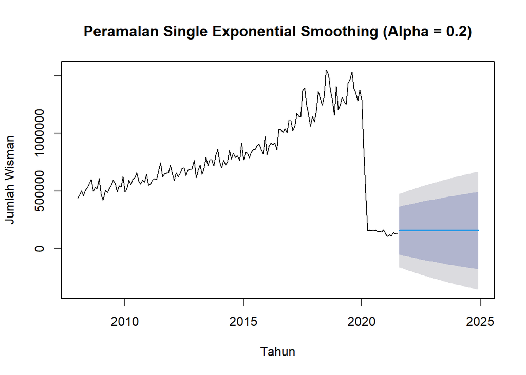

```r
# Plot SES alpha = 0.2
plot(ses.02,
     main = "Peramalan Single Exponential Smoothing (Alpha = 0.2)",
     xlab = "Tahun",
     ylab = "Jumlah Wisman")
```

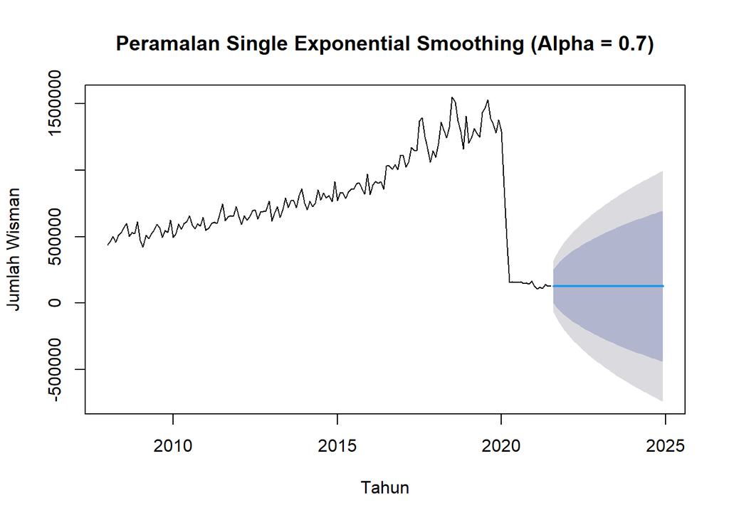

```r
# Plot SES alpha = 0.7
plot(ses.07,
     main = "Peramalan Single Exponential Smoothing (Alpha = 0.7)",
     xlab = "Tahun",
     ylab = "Jumlah Wisman")
```

Berdasarkan plot hasil peramalan SES, hasil ramalan terlihat lebih stabil dibandingkan data aktual. Garis ramalan tidak mengikuti perubahan data aktual secara langsung, terutama ketika terjadi perubahan jumlah wisatawan yang cukup besar.

## 6.3 Menentukan parameter alpha optimal

```r
# SES dengan parameter alpha yang dioptimalkan
ses.opt <- ses(train.ts, h = length(test.ts))

# Menampilkan hasil parameter optimal
ses.opt
```

```
##          Point Forecast      Lo 80    Hi 80       Lo 95     Hi 95
## Aug 2021         127249    9316.39 245181.5   -53113.34  307611.3
## Sep 2021         127249  -39524.54 294022.5  -127809.09  382307.0
## Oct 2021         127249  -77002.62 331500.5  -185126.87  439624.8
## Nov 2021         127249 -108598.48 363096.4  -233448.58  487946.5
## Dec 2021         127249 -136435.18 390933.1  -276021.13  530519.0
## Jan 2022         127249 -161601.58 416099.5  -314509.82  569007.7
## Feb 2022         127249 -184744.54 439242.5  -349903.92  604401.8
## Mar 2022         127249 -206285.52 460783.4  -382848.01  637345.9
## Apr 2022         127249 -226517.29 481015.2  -413789.83  668287.7
## May 2022         127249 -245652.99 500150.9  -443055.36  697553.3
## Jun 2022         127249 -263853.55 518351.5  -470890.72  725388.6
## Jul 2022         127249 -281243.98 535741.9  -497487.08  751985.0
## Aug 2022         127249 -297923.70 552421.6  -522996.51  777494.4
## Sep 2022         127249 -313973.32 568471.2  -547542.29  802040.2
## Oct 2022         127249 -329459.27 583957.2  -571226.01  825723.9
## Nov 2022         127249 -344437.08 598935.0  -594132.58  848630.5
## Dec 2022         127249 -358953.70 613451.6  -616333.84  870831.8
## Jan 2023         127249 -373049.29 627547.2  -637891.18  892389.1
## Feb 2023         127249 -386758.47 641256.4  -658857.57  913355.5
## Mar 2023         127249 -400111.40 654609.3  -679279.11  933777.0
## Apr 2023         127249 -413134.48 667632.4  -699196.19  953694.1
## May 2023         127249 -425851.00 680348.9  -718644.44  973142.4
## Jun 2023         127249 -438281.66 692779.6  -737655.48  992153.4
## Jul 2023         127249 -450444.89 704942.8  -756257.54 1010755.5
## Aug 2023         127249 -462357.26 716855.2  -774475.94 1028973.9
## Sep 2023         127249 -474033.67 728531.6  -792333.47 1046831.4
## Oct 2023         127249 -485487.61 739985.5  -809850.76 1064348.7
## Nov 2023         127249 -496731.34 751229.3  -827046.56 1081544.5
## Dec 2023         127249 -507776.02 762273.9  -843937.94 1098435.9
## Jan 2024         127249 -518631.86 773129.8  -860540.51 1115038.4
## Feb 2024         127249 -529308.23 783806.1  -876868.61 1131366.5
## Mar 2024         127249 -539813.74 794311.7  -892935.41 1147433.3
## Apr 2024         127249 -550156.36 804654.3  -908753.07 1163251.0
## May 2024         127249 -560343.41 814841.3  -924332.83 1178830.7
## Jun 2024         127249 -570381.73 824879.6  -939685.11 1194183.0
## Jul 2024         127249 -580277.64 834775.6  -954819.59 1209317.5
## Aug 2024         127249 -590037.03 844535.0  -969745.30 1224243.2
## Sep 2024         127249 -599665.41 854163.3  -984470.63 1238968.6
## Oct 2024         127249 -609167.91 863665.8  -999003.46 1253501.4
## Nov 2024         127249 -618549.35 873047.3 -1013351.13 1267849.0
## Dec 2024         127249 -627814.23 882312.2 -1027520.55 1282018.5
```

```r
# Melihat nilai alpha optimal
ses.opt$model$par
```

```
##       alpha           l
##      0.9999 509985.6318
```

Berdasarkan hasil optimasi parameter, diperoleh nilai **alpha optimal sebesar 0,9999**. Nilai tersebut sangat mendekati 1, sehingga model memberikan bobot yang sangat besar pada pengamatan terbaru dalam proses pemulusan.

Pada output model juga diperoleh nilai level awal sebesar **509.985,6318**. Dengan parameter tersebut, hasil peramalan untuk periode Agustus 2021 sampai Desember 2024 memiliki nilai **127.249** untuk setiap periode.

## 6.4 Peramalan dengan alpha optimal

```r
# Nilai ramalan dengan alpha optimal
ses.opt$mean
```

```
##         Jan    Feb    Mar    Apr    May    Jun    Jul    Aug    Sep    Oct
## 2021                                                  127249 127249 127249
## 2022 127249 127249 127249 127249 127249 127249 127249 127249 127249 127249
## 2023 127249 127249 127249 127249 127249 127249 127249 127249 127249 127249
## 2024 127249 127249 127249 127249 127249 127249 127249 127249 127249 127249
##         Nov    Dec
## 2021 127249 127249
## 2022 127249 127249
## 2023 127249 127249
## 2024 127249 127249
```

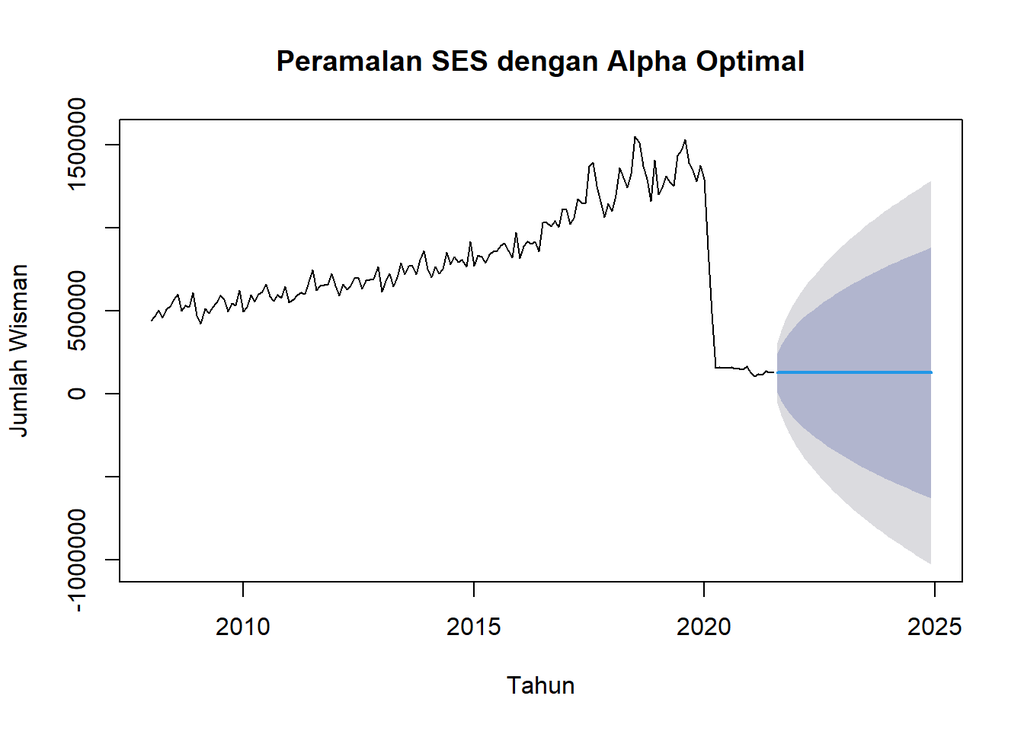

```r
# Plot hasil peramalan dengan alpha optimal
plot(ses.opt,
     main = "Peramalan SES dengan Alpha Optimal",
     xlab = "Tahun",
     ylab = "Jumlah Wisman")
```

Berdasarkan hasil peramalan dengan alpha optimal, seluruh nilai ramalan dari **Agustus 2021 sampai Desember 2024 adalah 127.249**. Artinya, model SES menghasilkan nilai ramalan yang sama untuk seluruh periode testing.

Pada plot, hasil ramalan tersebut terlihat relatif datar dan tidak mengikuti perubahan jumlah wisatawan pada periode testing. Oleh karena itu, model SES dengan alpha optimal belum dapat menggambarkan perubahan data aktual yang terjadi selama periode testing.

## 6.5 Akurasi data training

```r
# Mengambil fitted value dari model SES optimal
fitted.ses <- fitted(ses.opt)

# Menghitung error pada data training
error_train.ses <- train.ts - fitted.ses

# Menghilangkan nilai NA jika ada
error_train.ses <- na.omit(error_train.ses)

# Menghitung SSE, MSE, dan MAPE
SSE_train.ses <- sum(error_train.ses^2)
MSE_train.ses <- mean(error_train.ses^2)
MAPE_train.ses <- mean(abs(error_train.ses /
                            train.ts[!is.na(fitted(ses.opt))]) * 100)

# Membuat tabel akurasi training
akurasi_train.ses <- matrix(c(SSE_train.ses,
                              MSE_train.ses,
                              MAPE_train.ses))

row.names(akurasi_train.ses) <- c("SSE", "MSE", "MAPE")
colnames(akurasi_train.ses) <- c("SES Alpha Optimal")

akurasi_train.ses
```

```
##      SES Alpha Optimal
## SSE       1.363394e+12
## MSE       8.364377e+09
## MAPE      9.739316e+00
```

Berdasarkan hasil akurasi data training, diperoleh **SSE sebesar $1.363394\times10^{12}$**, **MSE sebesar $8.364377\times10^9$**, dan **MAPE sebesar 9,739316%**.

Nilai MAPE tersebut menunjukkan bahwa rata-rata kesalahan persentase hasil ramalan SES terhadap data aktual pada data training adalah sekitar **9,74%**.

## 6.6 Akurasi data testing

```r
# Mengambil hasil ramalan untuk data testing
ramalan_test.ses <- as.numeric(ses.opt$mean)

# Menghitung error data testing
error_test.ses <- as.numeric(test.ts) - ramalan_test.ses

# Menghitung SSE, MSE, dan MAPE
SSE_test.ses <- sum(error_test.ses^2)
MSE_test.ses <- mean(error_test.ses^2)
MAPE_test.ses <- mean(abs(error_test.ses /
                           as.numeric(test.ts)) * 100)

# Membuat tabel akurasi testing
akurasi_test.ses <- matrix(c(SSE_test.ses,
                             MSE_test.ses,
                             MAPE_test.ses))

row.names(akurasi_test.ses) <- c("SSE", "MSE", "MAPE")
colnames(akurasi_test.ses) <- c("SES Alpha Optimal")

akurasi_test.ses
```

```
##      SES Alpha Optimal
## SSE       2.418656e+13
## MSE       5.899161e+11
## MAPE      7.030509e+01
```

Pada data testing, diperoleh **SSE sebesar $2.418656\times10^{13}$**, **MSE sebesar $5.899161\times10^{11}$**, dan **MAPE sebesar 70,30509%**.

Nilai MAPE pada data testing jauh lebih besar dibandingkan dengan MAPE pada data training. Hal ini menunjukkan bahwa kesalahan peramalan meningkat ketika model digunakan untuk meramalkan data pada periode testing.

# 7. Double Exponential Smoothing (DES)

## 7.1 Pemodelan DES

```r
# Alpha = 0.2 dan Beta = 0.2
des.02 <- HoltWinters(train.ts,
                      gamma = FALSE,
                      beta = 0.2,
                      alpha = 0.2)

des.02
```

```
## Holt-Winters exponential smoothing with trend and without seasonal component.
##
## Call:
## HoltWinters(x = train.ts, alpha = 0.2, beta = 0.2, gamma = FALSE)
##
## Smoothing parameters:
##  alpha: 0.2
##  beta : 0.2
##  gamma: FALSE
##
## Coefficients:
##         [,1]
## a -62755.263
## b  -6335.977
```

Pada metode **Double Exponential Smoothing (DES)** digunakan nilai awal $\alpha=0.2$ dan $\beta=0.2$. Berdasarkan hasil pemodelan, diperoleh koefisien $a=-62.755,263$ dan $b=-6.335,977$. Nilai koefisien tren $b$ yang negatif menunjukkan adanya kecenderungan penurunan pada hasil pemulusan model dengan parameter tersebut.

## 7.2 Plot hasil pemulusan dan peramalan

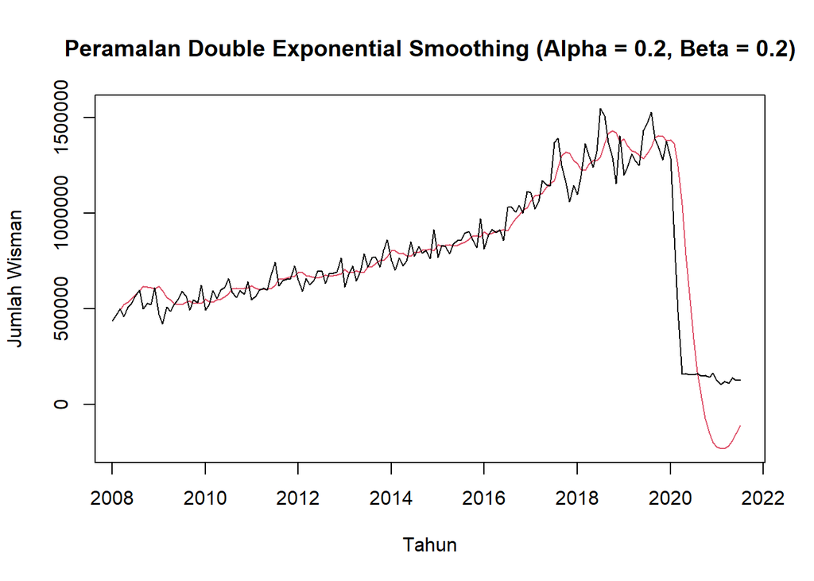

```r
plot(des.02,
     main = "Peramalan Double Exponential Smoothing (Alpha = 0.2, Beta = 0.2)",
     xlab = "Tahun",
     ylab = "Jumlah Wisman")
```

Berdasarkan plot pemulusan DES dengan $\alpha=0.2$ dan $\beta=0.2$, hasil pemulusan lebih halus dibandingkan data aktual. DES melakukan pemulusan pada level dan tren sehingga perubahan data tidak langsung diikuti oleh hasil pemulusan.

## 7.3 Parameter Alpha dan Beta Optimal

```r
des.opt <- HoltWinters(train.ts,
                       gamma = FALSE)

des.opt
```

```
## Holt-Winters exponential smoothing with trend and without seasonal component.
##
## Call:
## HoltWinters(x = train.ts, gamma = FALSE)
##
## Smoothing parameters:
##  alpha: 1
##  beta : 0.02844065
##  gamma: FALSE
##
## Coefficients:
##        [,1]
## a 127249.00
## b -17860.02
```

```r
# Menampilkan parameter optimal
des.opt$alpha
```

```
## alpha
##     1
```

```r
des.opt$beta
```

```
##       beta
## 0.02844065
```

Berdasarkan hasil optimasi parameter, diperoleh **alpha optimal sebesar 1** dan **beta optimal sebesar 0,02844065**. Nilai alpha sebesar 1 menunjukkan bahwa model memberikan bobot yang sangat besar pada pengamatan terbaru dalam menentukan level. Sementara itu, nilai beta yang relatif kecil menunjukkan bahwa perubahan komponen tren diperbarui secara lebih perlahan.

Pada model optimal juga diperoleh koefisien $a=127.249,00$ dan $b=-17.860,02$. Nilai $b$ yang negatif menunjukkan bahwa model memperkirakan adanya kecenderungan penurunan pada periode setelah data training.

## 7.4 Peramalan dengan parameter optimal

```r
ramalan.des <- predict(des.opt,
                       n.ahead = length(test.ts))

ramalan.des
```

```
##              Jan         Feb         Mar         Apr         May         Jun
## 2021
## 2022   20088.878    2228.858  -15631.162  -33491.183  -51351.203  -69211.223
## 2023 -194231.365 -212091.385 -229951.406 -247811.426 -265671.446 -283531.466
## 2024 -408551.608 -426411.629 -444271.649 -462131.669 -479991.689 -497851.710
##              Jul         Aug         Sep         Oct         Nov         Dec
## 2021              109388.980   91528.959   73668.939   55808.919   37948.899
## 2022  -87071.243 -104931.264 -122791.284 -140651.304 -158511.324 -176371.345
## 2023 -301391.487 -319251.507 -337111.527 -354971.548 -372831.568 -390691.588
## 2024 -515711.730 -533571.750 -551431.771 -569291.791 -587151.811 -605011.831
```

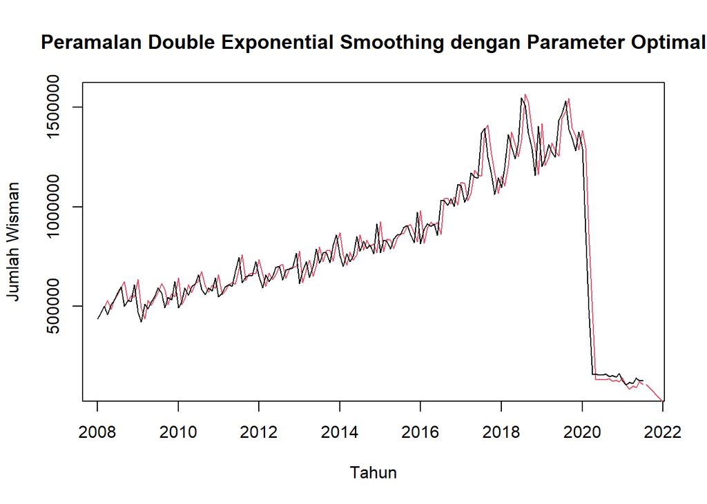

```r
# Plot hasil peramalan DES dengan parameter optimal
plot(des.opt,
     main = "Peramalan Double Exponential Smoothing dengan Parameter Optimal",
     xlab = "Tahun",
     ylab = "Jumlah Wisman")

lines(ramalan.des,
      col = 2)
```

Berdasarkan hasil peramalan dengan parameter optimal, nilai ramalan mulai dari sekitar **109.388,980 pada Agustus 2021**, kemudian terus menurun pada periode berikutnya. Ramalan menjadi negatif pada periode selanjutnya dan mencapai sekitar **-605.011,831 pada Desember 2024**.

Hasil tersebut menunjukkan bahwa DES dengan parameter optimal menghasilkan pola ramalan yang terus menurun. Pola ini berbeda cukup jauh dengan data aktual pada periode testing yang berada pada nilai positif dan menunjukkan peningkatan setelah periode 2021.

Dengan demikian, hasil peramalan DES pada bagian ini menunjukkan bahwa model belum dapat mengikuti pola perubahan jumlah wisatawan pada periode testing dengan baik.

## 7.5 Akurasi Data Training

```r
fitted.des <- fitted(des.opt)

# Mengambil nilai fitted
fitted_train.des <- fitted.des[, "xhat"]

# Menentukan data aktual dengan panjang yang sama
actual_train.des <- tail(
  train.ts,
  length(fitted_train.des)
)

# Menghitung error
error_train.des <- actual_train.des - fitted_train.des

# Menghapus NA jika ada
valid.des <- !is.na(error_train.des)

error_train.des <- error_train.des[valid.des]
actual_train.des <- actual_train.des[valid.des]

# Menghitung SSE
SSE_train.des <- sum(error_train.des^2)

# Menghitung MSE
MSE_train.des <- mean(error_train.des^2)

# Menghitung MAPE
MAPE_train.des <- mean(
  abs(error_train.des / actual_train.des) * 100
)

# Menampilkan hasil akurasi
akurasi_train.des <- matrix(
  c(SSE_train.des,
    MSE_train.des,
    MAPE_train.des)
)

row.names(akurasi_train.des) <- c("SSE", "MSE", "MAPE")

colnames(akurasi_train.des) <- c("DES Parameter Optimal")

akurasi_train.des
```

```
##      DES Parameter Optimal
## SSE           1.381647e+12
## MSE           8.581657e+09
## MAPE          1.025430e+01
```

Berdasarkan hasil akurasi data training, diperoleh **SSE sebesar $1,381647\times10^{12}$**, **MSE sebesar $8,581657\times10^9$**, dan **MAPE sebesar 10,25430%**.

Nilai MAPE tersebut menunjukkan bahwa rata-rata kesalahan persentase hasil pemulusan dan peramalan DES terhadap data aktual pada data training adalah sekitar **10,25%**.

## 7.6 Akurasi Data Testing

```r
ramalan_test.des <- as.numeric(ramalan.des)

error_test.des <- as.numeric(test.ts) -
  ramalan_test.des

SSE_test.des <- sum(error_test.des^2)

MSE_test.des <- mean(error_test.des^2)

MAPE_test.des <- mean(
  abs(
    error_test.des /
      as.numeric(test.ts)
  ) * 100
)

akurasi_test.des <- matrix(
  c(SSE_test.des,
    MSE_test.des,
    MAPE_test.des)
)

row.names(akurasi_test.des) <- c("SSE", "MSE", "MAPE")

colnames(akurasi_test.des) <- c("DES Parameter Optimal")

akurasi_test.des
```

```
##      DES Parameter Optimal
## SSE           5.844717e+13
## MSE           1.425541e+12
## MAPE          1.182783e+02
```

Pada data testing, diperoleh **SSE sebesar $5,844717\times10^{13}$**, **MSE sebesar $1,425541\times10^{12}$**, dan **MAPE sebesar 118,2783%**.

Nilai MAPE pada data testing jauh lebih besar dibandingkan dengan MAPE pada data training. Hal ini menunjukkan bahwa kesalahan peramalan meningkat secara cukup besar ketika model DES digunakan untuk meramalkan data yang belum digunakan dalam pembentukan model.

# 8 Holt-Winters

## 8.1 Holt-Winters Aditif

```r
# Pemodelan Holt-Winters aditif
winter.add <- HoltWinters(
  train.ts,
  seasonal = "additive"
)

winter.add
```

```
## Holt-Winters exponential smoothing with trend and additive seasonal component.
##
## Call:
## HoltWinters(x = train.ts, seasonal = "additive")
##
## Smoothing parameters:
##  alpha: 1
##  beta : 0
##  gamma: 0
##
## Coefficients:
##             [,1]
## a     82384.6007
## b       577.2901
## s1    77368.6910
## s2   -19676.7674
## s3     7143.5243
## s4      215.6910
## s5    85076.6076
## s6   -54192.4340
## s7  -105525.0174
## s8   -14102.3507
## s9   -38734.8924
## s10   -5174.0174
## s11   22736.5660
## s12   44864.3993
```

```r
# Menampilkan parameter optimal
winter.add$alpha
```

```
## alpha
##     1
```

```r
winter.add$beta
```

```
## beta
##    0
```

```r
winter.add$gamma
```

```
## gamma
##     0
```

```r
# Melihat hasil pemulusan
winter.add$fitted
```

```
##                xhat      level    trend      season
## Jan 2009  465921.33  519536.47 577.2901  -54192.434
## Feb 2009  422409.71  527357.43 577.2901 -105525.017
## Mar 2009  513554.96  527080.02 577.2901  -14102.351
## Apr 2009  487258.75  525416.35 577.2901  -38734.892
## May 2009  521259.17  525855.89 577.2901   -5174.017
## Jun 2009  550222.87  526909.02 577.2901   22736.566
## Jul 2009  573287.12  527845.43 577.2901   44864.399
## Aug 2009  626496.58  548550.60 577.2901   77368.691
## Sep 2009  470328.83  489428.31 577.2901  -19676.767
## Oct 2009  521196.58  513475.77 577.2901    7143.524
## Nov 2009  540808.46  540015.48 577.2901     215.691
## Dec 2009  617107.21  531453.31 577.2901   85076.608
## Jan 2010  486727.25  540342.39 577.2901  -54192.434
## Feb 2010  443043.71  547991.43 577.2901 -105525.017
## Mar 2010  615134.96  628660.02 577.2901  -14102.351
## Apr 2010  570186.75  608344.35 577.2901  -38734.892
## May 2010  590053.17  594649.89 577.2901   -5174.017
## Jun 2010  628518.87  605205.02 577.2901   22736.566
## Jul 2010  636127.12  590685.43 577.2901   44864.399
## Aug 2010  691557.58  613611.60 577.2901   77368.691
## Sep 2010  490061.83  509161.31 577.2901  -19676.767
## Oct 2010  587764.58  580043.77 577.2901    7143.524
## Nov 2010  588303.46  587510.48 577.2901     215.691
## Dec 2010  663590.21  577936.31 577.2901   85076.608
## Jan 2011  505529.25  559144.39 577.2901  -54192.434
## Feb 2011  498065.71  603013.43 577.2901 -105525.017
## Mar 2011  660056.96  673582.02 577.2901  -14102.351
## Apr 2011  574012.75  612170.35 577.2901  -38734.892
## May 2011  642231.17  646827.89 577.2901   -5174.017
## Jun 2011  628678.87  605365.02 577.2901   22736.566
## Jul 2011  697107.12  651665.43 577.2901   44864.399
## Aug 2011  778532.58  700586.60 577.2901   77368.691
## Sep 2011  524615.83  543715.31 577.2901  -19676.767
## Oct 2011  677468.58  669747.77 577.2901    7143.524
## Nov 2011  649655.46  648862.48 577.2901     215.691
## Dec 2011  740386.21  654732.31 577.2901   85076.608
## Jan 2012  585847.25  639462.39 577.2901  -54192.434
## Feb 2012  601936.71  706884.43 577.2901 -105525.017
## Mar 2012  684501.96  698027.02 577.2901  -14102.351
```

[output cut: 97 more lines]

```
## May 2020  192204.17  196800.89 577.2901   -5174.017
## Jun 2020  190329.87  167016.02 577.2901   22736.566
## Jul 2020  179266.12  133824.43 577.2901   44864.399
## Aug 2020  188823.58  110877.60 577.2901   77368.691
## Sep 2020   65080.83   84180.31 577.2901  -19676.767
## Oct 2020  176381.58  168660.77 577.2901    7143.524
## Nov 2020  145942.46  145149.48 577.2901     215.691
## Dec 2020  229914.21  144260.31 577.2901   85076.608
## Jan 2021   25387.25   79002.39 577.2901  -54192.434
## Feb 2021   75759.71  180707.43 577.2901 -105525.017
## Mar 2021  197787.96  211313.02 577.2901  -14102.351
## Apr 2021   95923.75  134081.35 577.2901  -38734.892
## May 2021  146894.17  151490.89 577.2901   -5174.017
## Jun 2021  167920.87  144607.02 577.2901   22736.566
## Jul 2021  149549.12  104107.43 577.2901   44864.399
```

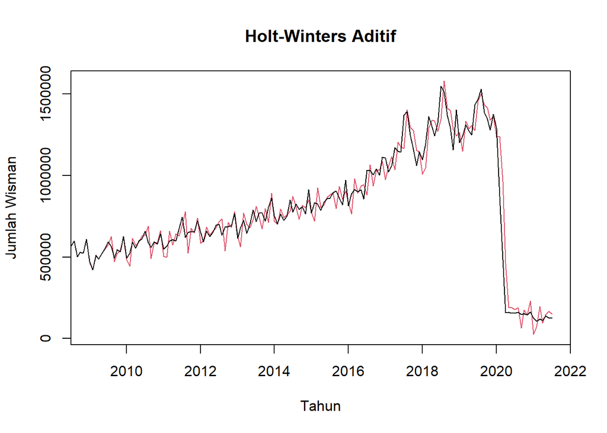

```r
# Plot hasil pemulusan Holt-Winters aditif
plot(
  winter.add,
  main = "Holt-Winters Aditif",
  xlab = "Tahun",
  ylab = "Jumlah Wisman"
)
```

Pada metode **Holt-Winters aditif**, diperoleh parameter optimal yaitu $\alpha=1$, $\beta=0$, dan $\gamma=0$. Nilai $\alpha=1$ menunjukkan bahwa model memberikan bobot yang sangat besar pada pengamatan terbaru dalam menentukan level. Sementara itu, nilai $\beta=0$ dan $\gamma=0$ menunjukkan bahwa pada hasil optimasi ini komponen tren dan musiman tidak diperbarui melalui parameter pemulusan.

## 8.2 Peramalan Holt-Winters Aditif

```r
# Melakukan peramalan untuk seluruh periode testing
ramalan.add <- predict(
  winter.add,
  n.ahead = length(test.ts)
)

ramalan.add
```

```
##             Jan        Feb        Mar        Apr        May        Jun
## 2021
## 2022  31655.907 -19099.386  72900.571  48845.319  82983.484 111471.357
## 2023  38583.388 -12171.905  79828.051  55772.800  89910.965 118398.838
## 2024  45510.869  -5244.425  86755.532  62700.280  96838.446 125326.319
##             Jul        Aug        Sep        Oct        Nov        Dec
## 2021            160330.582  63862.413  91259.995  84909.452 170347.659
## 2022 134176.481 167258.062  70789.894  98187.476  91836.933 177275.139
## 2023 141103.962 174185.543  77717.375 105114.957  98764.413 184202.620
## 2024 148031.442 181113.024  84644.856 112042.437 105691.894 191130.101
```

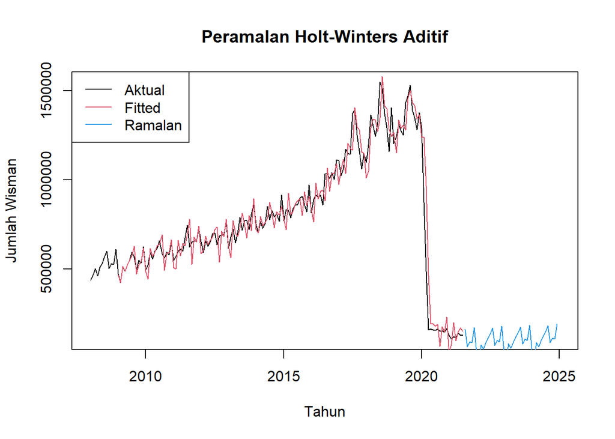

```r
# Plot peramalan Holt-Winters aditif
plot(
  train.ts,
  xlim = c(2008, 2025),
  main = "Peramalan Holt-Winters Aditif",
  xlab = "Tahun",
  ylab = "Jumlah Wisman"
)

lines(
  fitted(winter.add)[, "xhat"],
  col = 2
)

lines(
  ramalan.add,
  col = 4
)

legend(
  "topleft",
  legend = c("Aktual", "Fitted", "Ramalan"),
  col = c(1, 2, 4),
  lty = 1
)
```

Berdasarkan hasil peramalan, Holt-Winters aditif menghasilkan pola ramalan yang berbeda pada setiap bulan dan menunjukkan pola musiman. Namun, nilai ramalan yang dihasilkan relatif rendah dibandingkan dengan nilai aktual pada periode testing.

Sebagai contoh, hasil ramalan untuk **Agustus 2021 sebesar 160.330,582**, sedangkan pada periode berikutnya nilai ramalan masih berada pada kisaran yang relatif rendah. Hal ini menunjukkan bahwa model Holt-Winters aditif belum dapat mengikuti peningkatan jumlah wisatawan pada periode testing dengan baik.

## 8.3 Akurasi Training Holt-Winters Aditif

```r
# Mengambil nilai fitted
fitted.add <- fitted(winter.add)[, "xhat"]

# Menyesuaikan data aktual dengan panjang fitted
actual_train.add <- tail(
  train.ts,
  length(fitted.add)
)

# Menghitung error
error_train.add <- actual_train.add - fitted.add

# Menghitung SSE, MSE, dan MAPE
SSE_train.add <- sum(error_train.add^2)

MSE_train.add <- mean(error_train.add^2)

MAPE_train.add <- mean(
  abs(error_train.add / actual_train.add) * 100
)

# Menampilkan hasil akurasi
akurasi_train.add <- matrix(
  c(
    SSE_train.add,
    MSE_train.add,
    MAPE_train.add
  )
)

row.names(akurasi_train.add) <- c(
  "SSE",
  "MSE",
  "MAPE"
)

colnames(akurasi_train.add) <- c(
  "Holt-Winters Aditif"
)

akurasi_train.add
```

```
##      Holt-Winters Aditif
## SSE         1.123292e+12
## MSE         7.439023e+09
## MAPE        1.020307e+01
```

Berdasarkan hasil akurasi data training, diperoleh **SSE sebesar $1,123292\times10^{12}$**, **MSE sebesar $7,439023\times10^9$**, dan **MAPE sebesar 10,20307%**.

Nilai MAPE tersebut menunjukkan bahwa rata-rata kesalahan persentase hasil pemulusan Holt-Winters aditif terhadap data aktual pada data training adalah sekitar **10,20%**.

## 8.4 Akurasi Testing Holt-Winters Aditif

```r
# Mengubah hasil ramalan menjadi numerik
ramalan_test.add <- as.numeric(ramalan.add)

# Menghitung error testing
error_test.add <- as.numeric(test.ts) -
  ramalan_test.add

# Menghitung SSE, MSE, dan MAPE
SSE_test.add <- sum(error_test.add^2)

MSE_test.add <- mean(error_test.add^2)

MAPE_test.add <- mean(
  abs(
    error_test.add /
      as.numeric(test.ts)
  ) * 100
)

# Menampilkan hasil akurasi
akurasi_test.add <- matrix(
  c(
    SSE_test.add,
    MSE_test.add,
    MAPE_test.add
  )
)

row.names(akurasi_test.add) <- c(
  "SSE",
  "MSE",
  "MAPE"
)

colnames(akurasi_test.add) <- c(
  "Holt-Winters Aditif"
)

akurasi_test.add
```

```
##      Holt-Winters Aditif
## SSE         2.536727e+13
## MSE         6.187139e+11
## MAPE        8.123107e+01
```

Pada data testing, diperoleh **SSE sebesar $2,536727\times10^{13}$**, **MSE sebesar $6,187139\times10^{11}$**, dan **MAPE sebesar 81,23107%**.

Nilai MAPE pada data testing jauh lebih besar dibandingkan dengan data training. Hal ini menunjukkan bahwa kesalahan peramalan meningkat ketika model Holt-Winters aditif digunakan untuk meramalkan data pada periode yang belum digunakan dalam pembentukan model.

## 8.5 Holt-Winters Multiplikatif

```r
# Pemodelan Holt-Winters multiplikatif
winter.mult <- HoltWinters(
  train.ts,
  seasonal = "multiplicative"
)

winter.mult
```

```
## Holt-Winters exponential smoothing with trend and multiplicative seasonal component.
##
## Call:
## HoltWinters(x = train.ts, seasonal = "multiplicative")
##
## Smoothing parameters:
##  alpha: 0.8492963
##  beta : 0
##  gamma: 1
##
## Coefficients:
##             [,1]
## a   1.202363e+05
## b   5.772901e+02
## s1  1.096496e+00
## s2  1.014647e+00
## s3  1.003907e+00
## s4  9.664992e-01
## s5  1.119034e+00
## s6  9.700105e-01
## s7  8.711674e-01
## s8  8.548403e-01
## s9  6.930689e-01
## s10 8.827715e-01
## s11 9.566940e-01
## s12 1.058325e+00
```

```r
# Menampilkan parameter optimal
winter.mult$alpha
```

```
##     alpha
## 0.8492963
```

```r
winter.mult$beta
```

```
## beta
##    0
```

```r
winter.mult$gamma
```

```
## gamma
##     1
```

```r
# Melihat hasil pemulusan
winter.mult$fitted
```

```
##                xhat     level    trend    season
## Jan 2009  466578.77  519536.5 577.2901 0.8970706
## Feb 2009  421354.36  526349.2 577.2901 0.7996454
## Mar 2009  513462.53  527139.6 577.2901 0.9729886
## Apr 2009  487555.56  525841.5 577.2901 0.9261743
## May 2009  521330.78  526020.3 577.2901 0.9899984
## Jun 2009  550140.35  526944.4 577.2901 1.0428773
## Jul 2009  573742.94  527881.3 577.2901 1.0856913
## Aug 2009  624997.09  543847.4 577.2901 1.1479956
## Sep 2009  482904.38  501367.8 577.2901 0.9620662
## Oct 2009  519062.90  511562.6 577.2901 1.0135177
## Nov 2009  536391.61  535683.6 577.2901 1.0002438
## Dec 2009  619003.03  532251.0 577.2901 1.1617309
## Jan 2010  483724.84  537518.7 577.2901 0.8989564
## Feb 2010  438389.80  547613.7 577.2901 0.7997027
## Mar 2010  621121.53  638191.6 577.2901 0.9723728
## Apr 2010  570325.26  615291.6 577.2901 0.9260498
## May 2010  597266.74  602653.0 577.2901 0.9901140
## Jun 2010  632246.40  605601.4 577.2901 1.0430033
## Jul 2010  645331.89  590850.4 577.2901 1.0911426
## Aug 2010  680828.40  601658.4 577.2901 1.1305015
## Sep 2010  513498.46  531393.5 577.2901 0.9652757
## Oct 2010  586076.88  573208.0 577.2901 1.0214220
## Nov 2010  580858.48  580917.0 577.2901 0.9989066
## Dec 2010  674580.15  579193.2 577.2901 1.1635297
## Jan 2011  503333.89  557610.4 577.2901 0.9017288
## Feb 2011  493146.17  601029.9 577.2901 0.8197146
## Mar 2011  656542.18  679221.3 577.2901 0.9657892
## Apr 2011  580177.05  628377.6 577.2901 0.9224463
## May 2011  649207.43  654657.1 577.2901 0.9908019
## Jun 2011  637243.90  613218.4 577.2901 1.0382019
## Jul 2011  705658.81  644192.7 577.2901 1.0944349
## Aug 2011  746390.77  675649.3 577.2901 1.1037584
## Sep 2011  567383.75  579808.2 577.2901 0.9775981
## Oct 2011  668234.81  652220.7 577.2901 1.0236471
## Nov 2011  642073.08  642652.1 577.2901 0.9982024
## Dec 2011  756461.47  654183.7 577.2901 1.1553246
## Jan 2012  576983.63  631294.3 577.2901 0.9131343
## Feb 2012  587830.53  702287.1 577.2901 0.8363356
## Mar 2012  674026.47  707608.3 577.2901 0.9517654
```

[output cut: 97 more lines]

```
## May 2020  218906.13  233479.8 577.2901 0.9352679
## Jun 2020  186392.02  182238.4 577.2901 1.0195622
## Jul 2020  174091.17  157966.5 577.2901 1.0980639
## Aug 2020  158455.36  144351.6 577.2901 1.0933317
## Sep 2020  150271.15  147332.0 577.2901 1.0159681
## Oct 2020  147247.71  146833.3 577.2901 0.9988949
## Nov 2020  147665.88  151700.3 577.2901 0.9697151
## Dec 2020  168624.58  149483.8 577.2901 1.1237060
## Jan 2021  146123.50  146625.6 577.2901 0.9926675
## Feb 2021  115744.99  130426.4 577.2901 0.8835245
## Mar 2021  101934.94  121432.5 577.2901 0.8354655
## Apr 2021   95409.57  140352.5 577.2901 0.6770006
## May 2021  144994.91  162690.9 577.2901 0.8880782
## Jun 2021  157115.98  157949.1 577.2901 0.9911027
## Jul 2021  143670.57  132585.8 577.2901 1.0789072
```

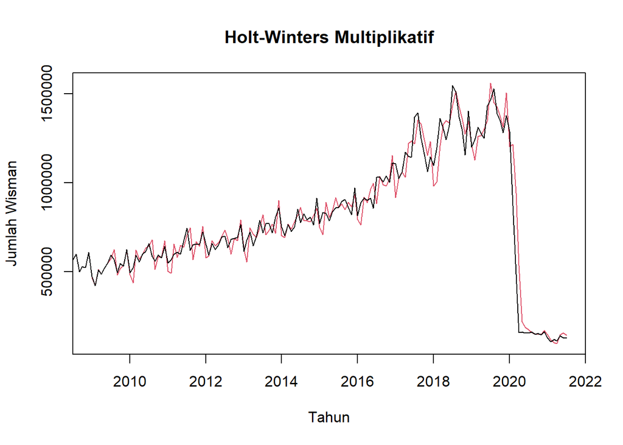

```r
# Plot hasil pemulusan Holt-Winters multiplikatif
plot(
  winter.mult,
  main = "Holt-Winters Multiplikatif",
  xlab = "Tahun",
  ylab = "Jumlah Wisman"
)
```

Pada metode **Holt-Winters multiplikatif**, diperoleh parameter optimal yaitu $\alpha=0,8492963$, $\beta=0$, dan $\gamma=1$.

Nilai $\alpha$ sebesar 0,8492963 menunjukkan bahwa pengamatan terbaru mendapatkan bobot yang cukup besar dalam menentukan level model. Nilai $\beta=0$ menunjukkan bahwa tidak terdapat pembaruan parameter tren melalui proses pemulusan, sedangkan $\gamma=1$ menunjukkan bahwa komponen musiman diperbarui dengan bobot yang besar.

Model juga menghasilkan 12 faktor musiman yang berbeda untuk setiap bulan. Hal ini menunjukkan bahwa model mempertimbangkan perubahan pola musiman bulanan secara relatif terhadap level data.

## 8.6 Peramalan Holt-Winters Multiplikatif

```r
# Melakukan peramalan untuk seluruh periode testing
ramalan.mult <- predict(
  winter.mult,
  n.ahead = length(test.ts)
)

ramalan.mult
```

```
##            Jan       Feb       Mar       Apr       May       Jun       Jul
## 2021
## 2022 119990.32 108266.34 106730.75  86932.95 111237.31 121104.52 134580.52
## 2023 126710.05 114301.33 112652.64  91734.17 117352.69 127732.00 141912.05
## 2024 133429.78 120336.33 118574.53  96535.39 123468.07 134359.48 149243.57
##            Aug       Sep       Oct       Nov       Dec
## 2021 132471.61 123168.87 122444.68 118440.07 137778.52
## 2022 140067.56 130197.82 129399.22 125135.47 145530.60
## 2023 147663.52 137226.77 136353.77 131830.87 153282.69
## 2024 155259.48 144255.72 143308.32 138526.28 161034.78
```

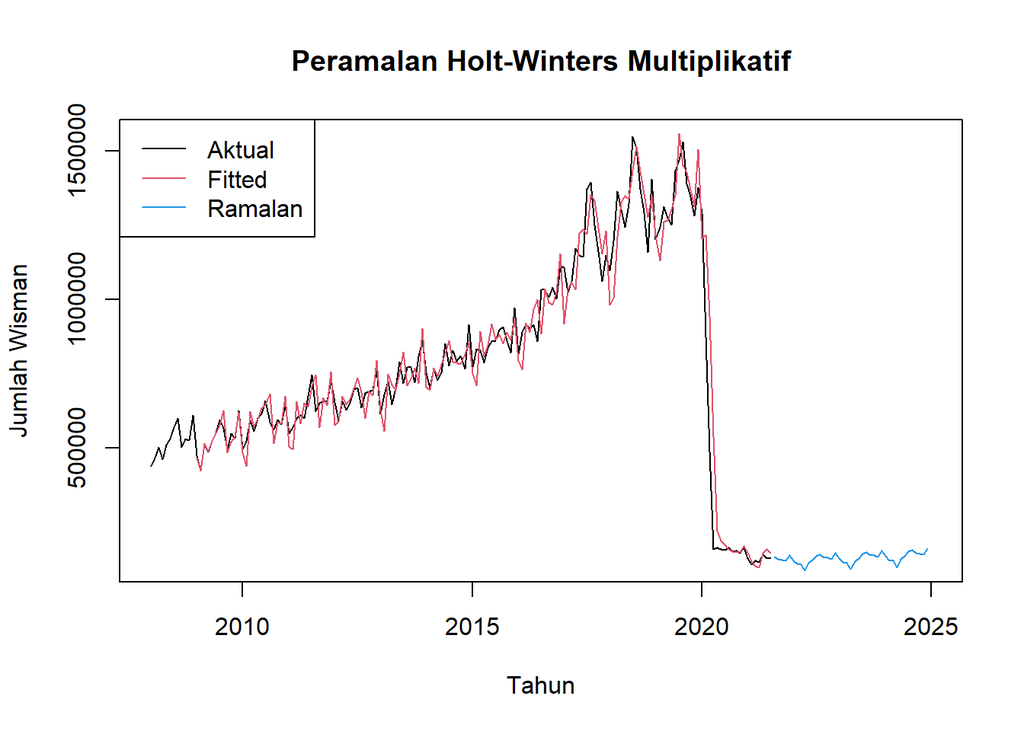

```r
# Plot peramalan Holt-Winters multiplikatif
plot(
  train.ts,
  xlim = c(2008, 2025),
  main = "Peramalan Holt-Winters Multiplikatif",
  xlab = "Tahun",
  ylab = "Jumlah Wisman"
)

lines(
  fitted(winter.mult)[, "xhat"],
  col = 2
)

lines(
  ramalan.mult,
  col = 4
)

legend(
  "topleft",
  legend = c("Aktual", "Fitted", "Ramalan"),
  col = c(1, 2, 4),
  lty = 1
)
```

Berdasarkan hasil peramalan, Holt-Winters multiplikatif menghasilkan pola yang mengikuti komponen musiman dan menunjukkan kecenderungan meningkat dari waktu ke waktu.

Pada periode testing, misalnya, hasil ramalan **Agustus 2021 sebesar 132.471,61**, kemudian meningkat menjadi **140.067,56 pada Agustus 2022**, **147.663,52 pada Agustus 2023**, dan **155.259,48 pada Agustus 2024**. Pola yang sama juga terlihat pada bulan-bulan lainnya.

Dengan demikian, model multiplikatif menghasilkan ramalan yang meningkat secara bertahap dan tetap mempertahankan pola musiman bulanan.

## 8.7 Akurasi Training Holt-Winters Multiplikatif

```r
# Mengambil nilai fitted
fitted.mult <- fitted(winter.mult)[, "xhat"]

# Menyesuaikan data aktual dengan panjang fitted
actual_train.mult <- tail(
  train.ts,
  length(fitted.mult)
)

# Menghitung error
error_train.mult <- actual_train.mult -
  fitted.mult

# Menghitung SSE, MSE, dan MAPE
SSE_train.mult <- sum(error_train.mult^2)

MSE_train.mult <- mean(error_train.mult^2)

MAPE_train.mult <- mean(
  abs(
    error_train.mult /
      actual_train.mult
  ) * 100
)

# Menampilkan hasil akurasi
akurasi_train.mult <- matrix(
  c(
    SSE_train.mult,
    MSE_train.mult,
    MAPE_train.mult
  )
)

row.names(akurasi_train.mult) <- c(
  "SSE",
  "MSE",
  "MAPE"
)

colnames(akurasi_train.mult) <- c(
  "Holt-Winters Multiplikatif"
)

akurasi_train.mult
```

```
##      Holt-Winters Multiplikatif
## SSE                1.045174e+12
## MSE                6.921679e+09
## MAPE               8.434563e+00
```

Berdasarkan hasil akurasi data training, diperoleh **SSE sebesar $1,045174\times10^{12}$**, **MSE sebesar $6,921679\times10^9$**, dan **MAPE sebesar 8,434563%**.

Nilai MAPE tersebut menunjukkan bahwa rata-rata kesalahan persentase hasil pemulusan Holt-Winters multiplikatif terhadap data aktual pada data training adalah sekitar **8,43%**.

## 8.8 Akurasi Testing Holt-Winters Multiplikatif

```r
# Mengubah hasil ramalan menjadi numerik
ramalan_test.mult <- as.numeric(ramalan.mult)

# Menghitung error testing
error_test.mult <- as.numeric(test.ts) -
  ramalan_test.mult

# Menghitung SSE, MSE, dan MAPE
SSE_test.mult <- sum(error_test.mult^2)

MSE_test.mult <- mean(error_test.mult^2)

MAPE_test.mult <- mean(
  abs(
    error_test.mult /
      as.numeric(test.ts)
  ) * 100
)

# Menampilkan hasil akurasi
akurasi_test.mult <- matrix(
  c(
    SSE_test.mult,
    MSE_test.mult,
    MAPE_test.mult
  )
)

row.names(akurasi_test.mult) <- c(
  "SSE",
  "MSE",
  "MAPE"
)

colnames(akurasi_test.mult) <- c(
  "Holt-Winters Multiplikatif"
)

akurasi_test.mult
```

```
##      Holt-Winters Multiplikatif
## SSE                2.388324e+13
## MSE                5.825180e+11
## MAPE               7.112316e+01
```

Pada data testing, diperoleh **SSE sebesar $2,388324\times10^{13}$**, **MSE sebesar $5,825180\times10^{11}$**, dan **MAPE sebesar 71,12316%**.

Nilai MAPE pada data testing lebih besar dibandingkan dengan data training. Hal ini menunjukkan bahwa kesalahan peramalan meningkat ketika model digunakan pada data yang belum digunakan dalam pembentukan model.

## 8.9 Ringkasan Akurasi Holt-Winters

```r
akurasi_HW <- cbind(
  akurasi_train.add,
  akurasi_train.mult
)

akurasi_HW
```

```
##      Holt-Winters Aditif Holt-Winters Multiplikatif
## SSE         1.123292e+12               1.045174e+12
## MSE         7.439023e+09               6.921679e+09
## MAPE        1.020307e+01               8.434563e+00
```

```r
akurasi_HW_test <- cbind(
  akurasi_test.add,
  akurasi_test.mult
)

akurasi_HW_test
```

```
##      Holt-Winters Aditif Holt-Winters Multiplikatif
## SSE         2.536727e+13               2.388324e+13
## MSE         6.187139e+11               5.825180e+11
## MAPE        8.123107e+01               7.112316e+01
```

Berdasarkan ringkasan akurasi, pada data training Holt-Winters multiplikatif menghasilkan **MAPE sebesar 8,434563%**, sedangkan Holt-Winters aditif menghasilkan **MAPE sebesar 10,20307%**.

Pada data testing, Holt-Winters multiplikatif menghasilkan **MAPE sebesar 71,12316%**, sedangkan Holt-Winters aditif menghasilkan **MAPE sebesar 81,23107%**. Nilai SSE dan MSE pada model multiplikatif juga lebih kecil dibandingkan model aditif pada data testing.

# 9. Perbandingan Metode

## 9.1 Perbandingan Metode Data Training

```r
# Menggabungkan akurasi data training
perbandingan_train <- cbind(
  akurasi_train.sma,
  akurasi_train.dma,
  akurasi_train.des,
  akurasi_train.add,
  akurasi_train.mult
)

# Menambahkan hasil SES
perbandingan_train <- cbind(
  perbandingan_train,
  akurasi_train.ses
)

# Mengubah nama kolom
colnames(perbandingan_train) <- c(
  "SMA",
  "DMA",
  "DES",
  "HW Aditif",
  "HW Multiplikatif",
  "SES"
)

# Menampilkan akurasi training
perbandingan_train
```

```
##               SMA          DMA          DES    HW Aditif HW Multiplikatif
## SSE  2.715596e+12 2.475110e+12 1.381647e+12 1.123292e+12     1.045174e+12
## MSE  1.707922e+10 1.586609e+10 8.581657e+09 7.439023e+09     6.921679e+09
## MAPE 1.508716e+01 1.731724e+01 1.025430e+01 1.020307e+01     8.434563e+00
##               SES
## SSE  1.363394e+12
## MSE  8.364377e+09
## MAPE 9.739316e+00
```

```r
# Perbandingan MAPE data training
MAPE_train <- perbandingan_train["MAPE", ]

MAPE_train
```

```
##              SMA              DMA              DES        HW Aditif
##        15.087160        17.317238        10.254296        10.203069
## HW Multiplikatif              SES
##         8.434563         9.739316
```

## 9.2 Perbandingan Metode Data Testing

```r
# Menggabungkan akurasi data testing
perbandingan_test <- cbind(
  akurasi_test.sma,
  akurasi_test.dma,
  akurasi_test.des,
  akurasi_test.add,
  akurasi_test.mult
)

# Menambahkan hasil SES
perbandingan_test <- cbind(
  perbandingan_test,
  akurasi_test.ses
)

# Mengubah nama kolom
colnames(perbandingan_test) <- c(
  "SMA",
  "DMA",
  "DES",
  "HW Aditif",
  "HW Multiplikatif",
  "SES"
)

# Menampilkan akurasi testing
perbandingan_test
```

```
##               SMA          DMA          DES    HW Aditif HW Multiplikatif
## SSE  2.422315e+13 2.379389e+13 5.844717e+13 2.536727e+13     2.388324e+13
## MSE  5.908085e+11 5.803388e+11 1.425541e+12 6.187139e+11     5.825180e+11
## MAPE 7.038539e+01 6.943804e+01 1.182783e+02 8.123107e+01     7.112316e+01
##               SES
## SSE  2.418656e+13
## MSE  5.899161e+11
## MAPE 7.030509e+01
```

```r
# Perbandingan MAPE data testing
MAPE_test <- perbandingan_test["MAPE", ]

MAPE_test
```

```
##              SMA              DMA              DES        HW Aditif
##         70.38539         69.43804        118.27831         81.23107
## HW Multiplikatif              SES
##         71.12316         70.30509
```

## 9.3 Perbandingan Nilai MAPE Data Training dan Data Testing

```r
# Tabel perbandingan MAPE
perbandingan_MAPE <- rbind(
  Training = MAPE_train,
  Testing = MAPE_test
)

perbandingan_MAPE
```

```
##               SMA      DMA      DES HW Aditif HW Multiplikatif       SES
## Training 15.08716 17.31724  10.2543  10.20307         8.434563  9.739316
## Testing  70.38539 69.43804 118.2783  81.23107        71.123161 70.305086
```

**Interpretasi:**

Pada **data training**, nilai MAPE yang diperoleh adalah **15,08716% untuk SMA**, **17,31724% untuk DMA**, **10,25430% untuk DES**, **10,20307% untuk Holt-Winters Aditif**, **8,43456% untuk Holt-Winters Multiplikatif**, dan **9,73932% untuk SES**. Nilai MAPE tersebut menunjukkan bahwa tingkat kesalahan masing-masing metode pada data training berada pada nilai yang berbeda.

Pada **data testing**, diperoleh nilai MAPE sebesar **70,38539% untuk SMA**, **69,43804% untuk DMA**, **118,27831% untuk DES**, **81,23107% untuk Holt-Winters Aditif**, **71,12316% untuk Holt-Winters Multiplikatif**, dan **70,30509% untuk SES**. Terlihat bahwa nilai MAPE pada data testing lebih besar dibandingkan dengan data training pada seluruh metode.

Perbedaan nilai MAPE antara data training dan testing menunjukkan bahwa kesalahan peramalan meningkat ketika model digunakan untuk meramalkan data yang belum digunakan dalam pembentukan model. Peningkatan tersebut cukup besar terutama pada metode DES dan Holt-Winters Aditif, sedangkan metode lainnya juga mengalami peningkatan kesalahan pada data testing.

Berdasarkan hasil perbandingan tersebut, dapat dilihat bahwa setiap metode memberikan tingkat kesalahan yang berbeda pada data training dan testing. Oleh karena itu, hasil SSE, MSE, dan MAPE pada bagian ini dapat digunakan sebagai dasar untuk pembahasan lebih lanjut mengenai hasil keseluruhan metode peramalan.

# 10. Kesimpulan

Berdasarkan hasil analisis data jumlah wisatawan mancanegara Indonesia periode **Januari 2008 sampai Desember 2024**, diperoleh sebanyak **204 observasi**. Data kemudian dibagi menjadi data training sebanyak **163 observasi** pada periode Januari 2008 sampai Juli 2021 dan data testing sebanyak **41 observasi** pada periode Agustus 2021 sampai Desember 2024.

Peramalan dilakukan menggunakan enam metode, yaitu **Single Moving Average (SMA), Double Moving Average (DMA), Single Exponential Smoothing (SES), Double Exponential Smoothing (DES), Holt-Winters Aditif, dan Holt-Winters Multiplikatif**. Berdasarkan hasil pengukuran akurasi menggunakan SSE, MSE, dan MAPE, setiap metode menghasilkan tingkat kesalahan yang berbeda pada data training maupun data testing.

Pada data training, nilai MAPE yang diperoleh adalah **15,08716% untuk SMA**, **17,31724% untuk DMA**, **10,25430% untuk DES**, **10,20307% untuk Holt-Winters Aditif**, **8,43456% untuk Holt-Winters Multiplikatif**, dan **9,73932% untuk SES**. Sementara itu, pada data testing diperoleh MAPE sebesar **70,38539% untuk SMA**, **69,43804% untuk DMA**, **118,27831% untuk DES**, **81,23107% untuk Holt-Winters Aditif**, **71,12316% untuk Holt-Winters Multiplikatif**, dan **70,30509% untuk SES**.

Dari hasil tersebut terlihat bahwa seluruh metode menghasilkan nilai MAPE yang lebih besar pada data testing dibandingkan data training. Hal ini menunjukkan bahwa kesalahan peramalan meningkat ketika metode digunakan untuk meramalkan data yang belum digunakan dalam pembentukan model.

Selain itu, hasil peramalan menunjukkan bahwa karakteristik masing-masing metode memengaruhi bentuk ramalan yang dihasilkan. SMA dan DMA menghasilkan pemulusan yang lebih halus, SES menghasilkan ramalan yang relatif stabil, sedangkan DES menghasilkan pola penurunan yang cukup tajam pada periode testing. Holt-Winters dapat mempertimbangkan pola musiman bulanan, baik dengan pendekatan aditif maupun multiplikatif.

Secara keseluruhan, penerapan beberapa metode peramalan pada data jumlah wisatawan mancanegara menunjukkan adanya perbedaan hasil dan tingkat kesalahan antara data training dan testing. Oleh karena itu, hasil akurasi dari masing-masing metode dapat digunakan sebagai bahan pertimbangan dalam memilih metode peramalan yang sesuai dengan karakteristik data yang digunakan.